# EPIC2: From ATAC accessibility to trait-associated cell groups

TC and SCZ across all fetal-tissue cell groups

Lingxuan Zhu

2026-11-02

[**TC / SCZ test data**69.3 MB · ATAC, GWAS, genotypes & fragmentsDownload inputs ↓](https://www.dropbox.com/scl/fi/klue9o5srmc1rwu85pxnu/EPIC2_inputs_TC_SCZ_all_celltypes.tar.gz?rlkey=n9qx404r8aao8ivwbax2mj6yy&st=mm48yz5c&dl=1)

This tutorial runs EPIC2 on total cholesterol (**TC**) and schizophrenia (**SCZ**) with **4,788 cells**, **24 tissue–cell-type groups**, and **7 tissues**. Each trait starts with **5,000 sampled SNPs** and **503 reference individuals**. The ATAC object retains all **915,345 post-QC peak rows**. TC is the detailed example; both traits are analyzed in every stage.

All R code used to load the supplied inputs into EPIC2, execute the analysis, read results, and produce the displayed tables and figures is shown below. EPIC2’s analysis algorithms are called through its package functions. Run the installation commands separately before starting the analysis. Matrix previews show small slices; they do not subset the analysis.

These randomly reduced inputs demonstrate the software workflow. They are not the complete manuscript dataset and need not reproduce its association P-values.

# 1 Install the software and obtain the inputs

## 1.1 Install EPIC2

Run installation once before starting the analysis, then restart R. For a GitHub installation, use either of the following alternatives:

```r
if (!requireNamespace("devtools", quietly = TRUE)) install.packages("devtools")
devtools::install_github(
  "LingxuanZ/EPIC2", dependencies = NA,
  upgrade = "never", build_vignettes = FALSE
)
```

```r
if (!requireNamespace("remotes", quietly = TRUE)) install.packages("remotes")
remotes::install_github(
  "LingxuanZ/EPIC2", dependencies = NA,
  upgrade = "never", build_vignettes = FALSE
)
```

These commands install EPIC2’s required package dependencies. The complete workflow also uses optional analysis packages. The repository’s dependency script installs them:

```bash
git clone https://github.com/LingxuanZ/EPIC2.git
Rscript EPIC2/scripts/install_dependencies.R
```

## 1.2 Download the test data

[**TC / SCZ test data**69.3 MB · ATAC, GWAS, genotypes & fragmentsDownload inputs ↓](https://www.dropbox.com/scl/fi/klue9o5srmc1rwu85pxnu/EPIC2_inputs_TC_SCZ_all_celltypes.tar.gz?rlkey=n9qx404r8aao8ivwbax2mj6yy&st=mm48yz5c&dl=1)

The test-data archive is available from Dropbox. The archive contains the `data/` directory, including reference genotypes, fragments, their index, and preparation manifests.

Place the input archive in the working directory. The following code verifies the archive, extracts it when needed, and checks every data file. It never substitutes the older eight-trait example inputs.

```r
knitr::opts_chunk$set(
  echo = TRUE, include = TRUE, message = FALSE, warning = TRUE,
  error = FALSE, collapse = TRUE, comment = "#>",
  fig.width = 10, fig.height = 6, fig.align = "center",
  out.width = "100%", dpi = 160
)
required_packages <- c(
  "EPIC2", "Matrix", "Seurat", "SeuratObject", "Signac", "GenomicRanges",
  "BiocParallel", "Rsamtools", "presto", "ggplot2", "yaml", "knitr", "digest"
)
missing_packages <- required_packages[!vapply(
  required_packages, requireNamespace, logical(1), quietly = TRUE
)]
if (length(missing_packages)) {
  stop("Install missing packages before running the analysis: ", paste(missing_packages, collapse = ", "))
}
stopifnot(utils::packageVersion("EPIC2") >= "0.3.0")
library(EPIC2)
```

```r
archive <- "EPIC2_inputs_TC_SCZ_all_celltypes.tar.gz"
archive_sha256 <- "a459ee506c640cef69d72d8f3dc4eeb05464e53a54acd28beece76aa74c33f7b"
if (!file.exists(archive)) {
  if (!nzchar(params$data_url)) {
    stop("Place the test-data archive in the working directory, or set data_url to its public download URL.")
  }
  download.file(params$data_url, destfile = archive, mode = "wb")
}
stopifnot(identical(digest::digest(file = archive, algo = "sha256"), archive_sha256))
if (!dir.exists("data")) utils::untar(archive, exdir = ".")
checksums <- read.delim("data/checksums.tsv", stringsAsFactors = FALSE)
input_paths <- file.path("data", checksums$file)
stopifnot(
  all(file.exists(input_paths)),
  identical(unname(tools::md5sum(input_paths)), checksums$md5),
  all(file.info(input_paths)$size == checksums$bytes)
)
cat("Verified", nrow(checksums), "data files and the archive SHA-256.\n")
```

```
#> Verified 16 data files and the archive SHA-256.
```

## 1.3 Table and matrix display functions

These functions format table and matrix previews.

```r
tutorial_display_value <- function(x) {
  if (is.factor(x)) x <- as.character(x)
  if (is.character(x)) {
    absolute <- !is.na(x) & grepl("^(/|[A-Za-z]:[/\\\\])", x)
    x[absolute] <- basename(x[absolute])
  }
  x
}

show_table <- function(x, n = 6, digits = 3, caption = NULL) {
  x <- as.data.frame(x, check.names = FALSE)
  if (is.finite(n)) x <- utils::head(x, as.integer(n))
  x[] <- lapply(x, tutorial_display_value)
  p_columns <- grep("^(p|pval|padj|p_value|pvalue|p_.*|pval_.*)$", names(x),
                     ignore.case = TRUE, value = TRUE)
  for (column in p_columns) {
    if (is.numeric(x[[column]])) {
      x[[column]] <- vapply(x[[column]], function(value) {
        if (is.na(value)) return(NA_character_)
        if (value == 0) return("0")
        format(value, digits = digits, scientific = is.finite(value) && abs(value) < 0.001, trim = TRUE)
      }, character(1))
    }
  }
  knitr::kable(x, format = "html", row.names = FALSE, digits = digits,
               caption = caption, escape = TRUE)
}

table_preview <- show_table

tutorial_as_matrix <- function(x) {
  if (is.null(dim(x))) return(matrix(x, ncol = 1L, dimnames = list(names(x), "value")))
  if (length(dim(x)) != 2L) stop("A two-dimensional object is required for this preview.")
  x
}

matrix_summary <- function(x) {
  original_class <- paste(class(x), collapse = "/")
  x <- tutorial_as_matrix(x)
  nonzero <- if (inherits(x, "Matrix")) Matrix::nnzero(x, na.counted = FALSE) else sum(x != 0, na.rm = TRUE)
  total <- as.double(nrow(x)) * as.double(ncol(x))
  data.frame(class = original_class, rows = nrow(x), columns = ncol(x),
             nonzero_entries = nonzero,
             nonzero_percent = if (total > 0) 100 * nonzero / total else 0,
             check.names = FALSE)
}

matrix_preview <- function(x, n = 6, informative = TRUE, digits = 3) {
  original_class <- paste(class(x), collapse = "/")
  x <- tutorial_as_matrix(x)
  columns <- seq_len(min(as.integer(n), ncol(x)))
  rows <- seq_len(min(as.integer(n), nrow(x)))
  rule <- "first rows and columns in stored order"
  if (isTRUE(informative) && length(columns) && nrow(x)) {
    probe <- x[, columns, drop = FALSE]
    nonzero <- if (inherits(probe, "Matrix")) Matrix::rowSums(probe != 0, na.rm = TRUE) else rowSums(probe != 0, na.rm = TRUE)
    candidates <- which(nonzero > 0)
    if (length(candidates)) {
      rows <- utils::head(candidates, n)
      rule <- "first nonzero rows among the displayed columns, preserving stored order"
    }
  }
  preview <- as.matrix(x[rows, columns, drop = FALSE])
  if (is.null(rownames(preview))) rownames(preview) <- as.character(rows)
  if (is.null(colnames(preview))) colnames(preview) <- paste0("column_", columns)
  shown <- data.frame(feature = rownames(preview), preview, check.names = FALSE, row.names = NULL)
  caption <- paste0(original_class, "; full dimensions ", format(nrow(x), big.mark = ","),
                    " × ", format(ncol(x), big.mark = ","), "; ", rule, ".")
  show_table(shown, n = Inf, digits = digits, caption = caption)
}
report_columns <- function(x, columns) x[, intersect(columns, names(x)), drop = FALSE]
read_result <- function(stage, filename) {
  path <- file.path(params$results_dir, stage, filename)
  if (!file.exists(path)) stop("Required result is missing: ", path)
  if (grepl("\\.rds$", path)) return(readRDS(path))
  read.delim(path, check.names = FALSE, stringsAsFactors = FALSE)
}
```

# 2 Inspect the real-data inputs

## 2.1 Required analysis input files

The TC/SCZ analysis uses the seven input files below, supplied in the **69.3 MB** test-data archive. File sizes are rounded on-disk sizes in decimal units (1 MB = 1,000,000 bytes).

| Required file | Used for | Data size | File size |
| --- | --- | --- | --- |
| `data/atac.rds` | Peak counts, cell annotations, normalization and UMAP coordinates | 915,345 peaks × 4,788 cells | 65.60 MB |
| `data/gwas/TC.rds` | TC association statistics and SNP positions | 5,000 variants | 99.65 KB |
| `data/gwas/SCZ.rds` | SCZ association statistics and SNP positions | 5,000 variants | 111.09 KB |
| `data/genotypes/TC.rds` | TC reference MAF and LD calculation | 5,000 variants × 503 individuals | 816.53 KB |
| `data/genotypes/SCZ.rds` | SCZ reference MAF and LD calculation | 5,000 variants × 503 individuals | 782.46 KB |
| `data/fragments.tsv.gz` | SNP-by-cell accessibility counting | 228,196 fragment records | 2.24 MB |
| `data/fragments.tsv.gz.tbi` | Indexed retrieval of fragments at SNP positions | Tabix index | 109.86 KB |

Use the same genome assembly for all coordinate-based inputs: GWAS variant positions, ATAC peaks and fragments, and reference-variant position mappings. The supplied test data use **hg19/GRCh37**.

## 2.2 How the supplied inputs were prepared

The sampling described in this section was completed **before these inputs were supplied**. The analysis reads those files directly without resampling cells or GWAS SNPs. All 4,788 input cells remain in the analysis. GWAS validation and removal of zero-coverage SNP rows are deterministic analysis filters.

The earlier input preparation started from a completed cell-QC and peak-QC checkpoint containing 84,238 cells. It sampled up to 200 cells without replacement from every tissue–cell-type group (seed `20261028`). Twenty-three groups supply 200 cells each; the adrenal stromal group supplies all 188 available cells. Both traits use the same cells and the original UMAP coordinates.

TC and SCZ each supply 5,000 randomly sampled eligible variants, using seeds `20261029` and `20261030`. Variants were sampled without ranking GWAS P-values, from previously LD-pruned, strand-unambiguous tables. Eligibility required usable statistics, GWAS MAF from 0.05 to 0.5, unique IDs and positions, a matching reference genotype, and overlap with a retained autosomal peak detected in the sampled cells. Reference-panel MAF is checked again during the EPIC2 GWAS stage.

All post-QC peak rows remain, including rows that become zero after cell sampling. The portable fragment file preserves coverage at the 9,863 unique bundled SNP positions. It contains 228,196 fragment records from the selected cells near these positions. The preparation recorded exact agreement with the original fragment counts for every bundled position and cell; the original source files are not required to run this tutorial.

**The reduced fragments cannot be used to recompute genome-wide FRIP, TSS scores, the full peak matrix, or accessibility at arbitrary additional loci.** This tutorial therefore starts from the supplied post-QC checkpoint and skips the ATAC preprocessing stage. Stored QC metrics remain source annotations.

```r
info <- readRDS("data/info.rds")
traits <- as.character(info$traits)
trait <- params$trait
stopifnot(identical(traits, c("TC", "SCZ")), trait %in% traits)
atac <- readRDS("data/atac.rds")
atac_counts <- SeuratObject::GetAssayData(atac, assay = "ATAC", layer = "counts")
metadata <- atac[[]]
gwas_input <- readRDS(file.path("data", "gwas", paste0(trait, ".rds")))
genotype_input <- readRDS(file.path("data", "genotypes", paste0(trait, ".rds")))
stopifnot(
  nrow(atac_counts) == 915345L, ncol(atac_counts) == 4788L,
  length(unique(metadata$tissue_cell_type)) == 24L,
  length(unique(metadata$tissue)) == 7L,
  identical(rownames(metadata), colnames(atac_counts)),
  identical(as.character(gwas_input$rsid), rownames(genotype_input))
)
input_manifest <- read.delim("data/trait_counts.tsv")
```

```r
show_table(input_manifest, n = Inf)
```

| trait | n_source_gwas | n_eligible | n_snps | n_reference_samples | n_overlapping_peaks | seed |
| --- | --- | --- | --- | --- | --- | --- |
| TC | 396599 | 63867 | 5000 | 503 | 4948 | 20261029 |
| SCZ | 634030 | 97195 | 5000 | 503 | 4951 | 20261030 |

## 2.3 ATAC: peaks × cells

The sparse ATAC matrix stores the original post-QC peak counts. The displayed slice selects informative entries without changing the matrix used by EPIC2.

```r
show_table(matrix_summary(atac_counts))
```

| class | rows | columns | nonzero_entries | nonzero_percent |
| --- | --- | --- | --- | --- |
| dgCMatrix | 915345 | 4788 | 6153994 | 0.14 |

```r
matrix_preview(atac_counts, n = 6)
```

dgCMatrix; full dimensions 915,345 × 4,788; first nonzero rows among the displayed columns, preserving stored order.

| feature | C00001 | C00002 | C00003 | C00004 | C00005 | C00006 |
| --- | --- | --- | --- | --- | --- | --- |
| chr1-1265478-1265787 | 0 | 0 | 0 | 1 | 0 | 0 |
| chr1-1478777-1479334 | 0 | 0 | 0 | 0 | 1 | 0 |
| chr1-1655413-1656342 | 0 | 0 | 0 | 2 | 0 | 0 |
| chr1-1783481-1783725 | 0 | 0 | 1 | 0 | 0 | 0 |
| chr1-1804520-1805456 | 0 | 0 | 0 | 0 | 1 | 0 |
| chr1-1812176-1812860 | 0 | 0 | 0 | 0 | 3 | 0 |

```r
show_table(data.frame(
  cell = rownames(metadata),
  report_columns(metadata, c("tissue", "tissue_cell_type", "TSS.enrichment",
                            "FRIP", "nCount_ATAC", "BlacklistRatio", "nucleosome_signal")),
  row.names = NULL, check.names = FALSE
), n = 6)
```

| cell | tissue | tissue_cell_type | TSS.enrichment | FRIP | nCount_ATAC | BlacklistRatio | nucleosome_signal |
| --- | --- | --- | --- | --- | --- | --- | --- |
| C00001 | adrenal | adrenal_Adrenocortical cells | 4.318 | 0.567 | 3823 | 0.009 | 0.956 |
| C00002 | adrenal | adrenal_Adrenocortical cells | 3.155 | 0.670 | 1341 | 0.008 | 1.557 |
| C00003 | adrenal | adrenal_Adrenocortical cells | 3.627 | 0.648 | 645 | 0.007 | 1.153 |
| C00004 | adrenal | adrenal_Adrenocortical cells | 4.497 | 0.620 | 3334 | 0.008 | 1.630 |
| C00005 | adrenal | adrenal_Adrenocortical cells | 3.176 | 0.674 | 1853 | 0.007 | 1.672 |
| C00006 | adrenal | adrenal_Adrenocortical cells | 4.813 | 0.725 | 1281 | 0.010 | 1.239 |

```r
group_counts <- as.data.frame(table(metadata$tissue_cell_type), stringsAsFactors = FALSE)
names(group_counts) <- c("group", "cells")
show_table(group_counts, n = Inf)
```

| group | cells |
| --- | --- |
| adrenal_Adrenocortical cells | 200 |
| adrenal_Chromaffin cells | 200 |
| adrenal_Stromal cells | 188 |
| cerebrum_Astrocytes | 200 |
| cerebrum_Astrocytes/Oligodendrocytes | 200 |
| cerebrum_Excitatory neurons | 200 |
| cerebrum_Inhibitory neurons | 200 |
| heart_Cardiomyocytes | 200 |
| intestine_ENS neurons | 200 |
| intestine_Intestinal epithelial cells | 200 |
| intestine_Lymphoid cells | 200 |
| intestine_Smooth muscle cells | 200 |
| intestine_Stromal cells | 200 |
| kidney_Mesangial cells | 200 |
| kidney_Metanephric cells | 200 |
| kidney_Ureteric bud cells | 200 |
| kidney_Vascular endothelial cells | 200 |
| liver_Erythroblasts | 200 |
| liver_Hepatoblasts | 200 |
| liver_Lymphoid cells | 200 |
| liver_Myeloid cells | 200 |
| liver_Vascular endothelial cells | 200 |
| lung_Bronchiolar and alveolar epithelial cells | 200 |
| lung_Stromal cells | 200 |

## 2.4 GWAS and reference genotypes

The GWAS table provides SNP IDs, coordinates, alleles, MAF, effect estimates, standard errors, and P-values. The reference matrix has variant rows and individual columns. These 503 individuals are reference samples, not ATAC cells. IDs establish row alignment; allele orientation must already be harmonized.

```r
show_table(report_columns(gwas_input, c("rsid", "chr", "pos", "A1", "A2", "MAF", "beta", "se", "P")), n = 6)
```

| rsid | chr | pos | A1 | A2 | MAF | beta | se | P |
| --- | --- | --- | --- | --- | --- | --- | --- | --- |
| rs10907178 | 1 | 1021583 | C | A | 0.157 | 0.019 | 0.011 | 0.0769 |
| rs10910032 | 1 | 2169079 | T | C | 0.121 | 0.002 | 0.009 | 0.385 |
| rs4233033 | 1 | 2368232 | C | T | 0.425 | -0.004 | 0.010 | 0.679 |
| rs10909912 | 1 | 3175371 | G | T | 0.197 | 0.013 | 0.007 | 0.0792 |
| rs9970944 | 1 | 3454592 | T | G | 0.207 | 0.009 | 0.008 | 0.175 |
| rs4074709 | 1 | 3796948 | T | G | 0.177 | 0.003 | 0.008 | 0.675 |

```r
show_table(matrix_summary(genotype_input))
```

| class | rows | columns | nonzero_entries | nonzero_percent |
| --- | --- | --- | --- | --- |
| matrix/array | 5000 | 503 | 1033814 | 41.106 |

```r
matrix_preview(genotype_input, n = 6)
```

matrix/array; full dimensions 5,000 × 503; first nonzero rows among the displayed columns, preserving stored order.

| feature | REF001 | REF002 | REF003 | REF004 | REF005 | REF006 |
| --- | --- | --- | --- | --- | --- | --- |
| rs10907178 | 0 | 1 | 0 | 0 | 0 | 0 |
| rs10910032 | 0 | 0 | 0 | 0 | 1 | 0 |
| rs4233033 | 1 | 1 | 1 | 0 | 0 | 1 |
| rs10909912 | 0 | 1 | 0 | 0 | 1 | 1 |
| rs9970944 | 0 | 0 | 1 | 1 | 0 | 0 |
| rs4074709 | 0 | 1 | 0 | 0 | 1 | 0 |

# 3 Configure the analysis

`model.require_all_components = FALSE` follows the package default: ACAT uses all available valid components and reports how many contributed.

```r
config_spec <- list(
  project = list(name = "EPIC2 TC SCZ tutorial", output_dir = params$results_dir),
  parameters = list(seed = 1000L, workers = as.integer(params$workers)),
  genome = list(build = "hg19", duplicate_action = "drop"),
  atac = list(
    input = "data/atac.rds", assay = "ATAC",
    tissue_column = "tissue", group_column = "tissue_cell_type",
    attach_fragments = FALSE, compute_qc_metrics = FALSE, recompute_embedding = FALSE
  ),
  gwas = list(
    columns = list(rsid = "rsid", chr = "chr", pos = "pos", a1 = "A1", a2 = "A2",
                   maf = "MAF", p = "P", beta = "beta", se = "se"),
    genotype_format = "dosage", genotype_orientation = "variants_by_samples",
    genotype_ploidy = 2L, maf_min = 0.05, reference_missing_rate_max = 0.01,
    ld_prune = FALSE, remove_ambiguous = FALSE,
    traits = setNames(lapply(traits, function(x) list(
      summary = file.path("data", "gwas", paste0(x, ".rds")),
      genotype = file.path("data", "genotypes", paste0(x, ".rds"))
    )), traits)
  ),
  accessibility = list(chunks = 20L),
  ld = list(window_bp = 5000000L, ridge = 0.01, eigen_tolerance = 1e-8,
            correlation_block_size = 256L, max_snps_for_chr_ld = 15000L,
            max_dense_block_size = 5000L),
  wrs = list(truncation_quantiles = c(0.02, 0.98), balanced = list(enabled = FALSE)),
  model = list(groupings = c("tissue_cell_type", "tissue"), require_all_components = FALSE),
  plots = list(formats = c("png", "pdf"), dpi = 180L, fail_on_error = TRUE,
               max_umap_cells = 4788L, ld_heatmap_max_features = 100L)
)
yaml::write_yaml(config_spec, "config.yml")
config <- EPIC2::read_EPIC2_config("config.yml", check_files = TRUE)
cat(yaml::as.yaml(config_spec))
```

```
#> project:
#>   name: EPIC2 TC SCZ tutorial
#>   output_dir: output
#> parameters:
#>   seed: 1000
#>   workers: 1
#> genome:
#>   build: hg19
#>   duplicate_action: drop
#> atac:
#>   input: data/atac.rds
#>   assay: ATAC
#>   tissue_column: tissue
#>   group_column: tissue_cell_type
#>   attach_fragments: no
#>   compute_qc_metrics: no
#>   recompute_embedding: no
#> gwas:
#>   columns:
#>     rsid: rsid
#>     chr: chr
#>     pos: pos
#>     a1: A1
#>     a2: A2
#>     maf: MAF
#>     p: P
#>     beta: beta
#>     se: se
#>   genotype_format: dosage
#>   genotype_orientation: variants_by_samples
#>   genotype_ploidy: 2
#>   maf_min: 0.05
#>   reference_missing_rate_max: 0.01
#>   ld_prune: no
#>   remove_ambiguous: no
#>   traits:
#>     TC:
#>       summary: data/gwas/TC.rds
#>       genotype: data/genotypes/TC.rds
#>     SCZ:
```

[output cut: 15 more lines]

```
#>   balanced:
#>     enabled: no
#> model:
#>   groupings:
#>   - tissue_cell_type
#>   - tissue
#>   require_all_components: no
#> plots:
#>   formats:
#>   - png
#>   - pdf
#>   dpi: 180
#>   fail_on_error: yes
#>   max_umap_cells: 4788
#>   ld_heatmap_max_features: 100
```

Set `run_analysis = TRUE` to run the analysis from the supplied inputs, or `FALSE` to regenerate the HTML using verified existing results. A fresh run archives previous outputs under `previous-runs/`.

```r
package_versions <- setNames(vapply(required_packages, function(x) {
  as.character(utils::packageVersion(x))
}, character(1)), required_packages)
namespace <- asNamespace("EPIC2")
function_names <- sort(ls(namespace, all.names = TRUE))
function_names <- function_names[vapply(function_names, function(x) {
  is.function(get(x, envir = namespace))
}, logical(1))]
source_fingerprint <- digest::digest(lapply(function_names, function(x) {
  f <- get(x, envir = namespace)
  list(name = x, formals = formals(f), body = body(f))
}), algo = "sha256")
analysis_key <- digest::digest(list(
  input_hashes = checksums[, c("file", "md5")], config = config_spec,
  package_versions = package_versions, source = source_fingerprint,
  R = R.version.string
), algo = "sha256")
record_file <- file.path(params$results_dir, "tutorial_run.rds")
stages <- c("gwas", "accessibility", "ld", "wrs", "model", "plot")
if (isTRUE(params$run_analysis)) {
  if (dir.exists(params$results_dir)) {
    previous_files <- list.files(params$results_dir, all.files = TRUE, no.. = TRUE)
    if (length(previous_files)) {
      dir.create("previous-runs", showWarnings = FALSE)
      previous_dir <- file.path("previous-runs", paste0(
        basename(params$results_dir), "-", format(Sys.time(), "%Y%m%dT%H%M%SZ", tz = "UTC"),
        "-", Sys.getpid()
      ))
      if (file.exists(previous_dir) || !file.rename(params$results_dir, previous_dir)) {
        stop("Cannot preserve existing results; choose a new results_dir and rerun.")
      }
      cat("Previous results saved to:", previous_dir, "\n")
    }
  }
  dir.create(params$results_dir, recursive = TRUE, showWarnings = FALSE)
  run_record <- list(status = "RUNNING", analysis_key = analysis_key,
                     started_utc = format(Sys.time(), tz = "UTC", usetz = TRUE),
                     package_versions = package_versions, source_fingerprint = source_fingerprint)
  saveRDS(run_record, record_file)
  stage_seconds <- setNames(numeric(length(stages)), stages)
} else {
  if (!file.exists(record_file)) stop("Run the analysis before rendering cached results.")
  run_record <- readRDS(record_file)
  stopifnot(identical(run_record$status, "COMPLETED"),
            identical(run_record$analysis_key, analysis_key))
  stage_seconds <- run_record$stage_seconds
}
cat("Render mode:", if (isTRUE(params$run_analysis)) "execute analysis" else "verified saved results", "\n")
```

```
#> Render mode: verified saved results
```

## 3.1 Which EPIC2 functions run here?

The analysis directly calls `read_EPIC2_config()`, `run_EPIC2()`, and `build_group_accessibility()`. The six calls to `run_EPIC2()` dispatch the following package stages during a fresh analysis:

| Stage | Package stage function | Main calculations called inside the stage |
| --- | --- | --- |
| GWAS | `run_gwas_stage()` | `harmonize_gwas()`; reference MAF, validity and identifier checks. |
| Accessibility | `run_accessibility_stage()` | `build_snp_accessibility()` from fragments; `build_peak_accessibility()` from stored peak counts. |
| LD | `run_ld_stage()` | `compute_snp_ld_covariance()`, `build_peak_ld_model_impl()`, and `compute_inverse_sqrt()` through connected components. |
| WRS | `run_wrs_stage()` | `run_wrs_matrix()` calls `presto::wilcoxauc()`; `make_one_sided_wrs()` constructs and truncates scores. |
| Models | `run_model_stage()` | `build_group_accessibility()`, `fit_whitened_groups()`, and `combine_component_tests()`. |
| Plots | `run_plot_stage()` | Reads saved results and generates the package’s PNG/PDF figures and manifest. |

The code also calls `build_group_accessibility()` directly to show the model predictors. `plot_annotation_umap()`, `plot_coverage_umap()`, and `plot_covariance()` below are tutorial display helpers; their full code is included. They read the same saved data and do not replace EPIC2’s statistical calculations.

ATAC QC and LD pruning are not run by this tutorial.

## 3.2 Attach fragments and prepare the post-QC checkpoint

The portable barcodes match the cell IDs in the Seurat object. The mapping uses Seurat cell names as names and fragment-file barcodes as values. Some retained cells have no fragments near the selected loci, so whole-file barcode presence validation is disabled for this deliberately reduced fragment file.

Setting `compute_qc_metrics = FALSE` alone would still allow filtering in the ATAC stage. We explicitly omit that stage and save the prepared object at the checkpoint consumed by the downstream stages. No cells or peak rows are removed.

```r
if (isTRUE(params$run_analysis)) {
  cell_ids <- colnames(atac)
  fragment <- Signac::CreateFragmentObject(
    path = normalizePath("data/fragments.tsv.gz"),
    cells = setNames(cell_ids, cell_ids),
    validate.fragments = FALSE, verbose = FALSE
  )
  Signac::Fragments(atac[["ATAC"]]) <- NULL
  Signac::Fragments(atac[["ATAC"]]) <- fragment
  checkpoint_dir <- file.path(params$results_dir, "01_atac")
  dir.create(checkpoint_dir, recursive = TRUE, showWarnings = FALSE)
  saveRDS(atac, file.path(checkpoint_dir, "atac.qc.rds"))
}
```

# 4 Validate GWAS and match reference genotypes

The first executed stage validates the common assembly and coordinates, matches reference variants, applies the configured GWAS/reference checks, and calculates the GWAS Z-score. LD pruning and ambiguous-SNP removal are disabled here because the source GWAS tables had already undergone those operations.

```r
if (isTRUE(params$run_analysis)) {
  stage_seconds["gwas"] <- system.time(
    invisible(EPIC2::run_EPIC2(config, stages = "gwas", gwas_name = traits))
  )[["elapsed"]]
}
```

**Generated files**  
`TC.gwas.rds` · `TC.genotype.rds` · `TC.gwas_qc.tsv`  
Stored in the `02_gwas` output folder.

```r
gwas <- read_result("02_gwas", paste0(trait, ".gwas.rds"))
genotype <- read_result("02_gwas", paste0(trait, ".genotype.rds"))
gwas_qc <- read_result("02_gwas", paste0(trait, ".gwas_qc.tsv"))
```

## 4.1 Filtered GWAS table and matched reference matrix

The new `coord_id` field uses `chr-position-position`: a **single-base** SNP interval. `Z` is the effect estimate divided by its standard error.

```r
show_table(report_columns(gwas, c("rsid", "chr", "pos", "coord_id", "Z",
                                 "EPIC2_reference_maf", "EPIC2_reference_missing_rate")), n = 6)
```

| rsid | chr | pos | coord_id | Z | EPIC2_reference_maf | EPIC2_reference_missing_rate |
| --- | --- | --- | --- | --- | --- | --- |
| rs10907178 | 1 | 1021583 | chr1-1021583-1021583 | 1.646 | 0.176 | 0 |
| rs10910032 | 1 | 2169079 | chr1-2169079-2169079 | 0.198 | 0.116 | 0 |
| rs4233033 | 1 | 2368232 | chr1-2368232-2368232 | -0.411 | 0.434 | 0 |
| rs10909912 | 1 | 3175371 | chr1-3175371-3175371 | 1.887 | 0.198 | 0 |
| rs9970944 | 1 | 3454592 | chr1-3454592-3454592 | 1.169 | 0.223 | 0 |
| rs4074709 | 1 | 3796948 | chr1-3796948-3796948 | 0.338 | 0.188 | 0 |

```r
matrix_preview(genotype, n = 6)
```

matrix/array; full dimensions 4,953 × 503; first nonzero rows among the displayed columns, preserving stored order.

| feature | REF001 | REF002 | REF003 | REF004 | REF005 | REF006 |
| --- | --- | --- | --- | --- | --- | --- |
| rs10907178 | 0 | 1 | 0 | 0 | 0 | 0 |
| rs10910032 | 0 | 0 | 0 | 0 | 1 | 0 |
| rs4233033 | 1 | 1 | 1 | 0 | 0 | 1 |
| rs10909912 | 0 | 1 | 0 | 0 | 1 | 1 |
| rs9970944 | 0 | 0 | 1 | 1 | 0 | 0 |
| rs4074709 | 0 | 1 | 0 | 0 | 1 | 0 |

```r
show_table(data.frame(
  check = c("GWAS rows", "Reference SNP rows", "Reference individuals",
            "GWAS and genotype IDs in identical order"),
  value = c(as.character(nrow(gwas)), as.character(nrow(genotype)),
            as.character(ncol(genotype)),
            as.character(identical(as.character(gwas$rsid), rownames(genotype))))
))
```

| check | value |
| --- | --- |
| GWAS rows | 4953 |
| Reference SNP rows | 4953 |
| Reference individuals | 503 |
| GWAS and genotype IDs in identical order | TRUE |

## 4.2 Retention diagnostics

These counts show what changed during EPIC2’s checks. A count can remain unchanged when the supplied processed input already satisfies a criterion. The prepared inputs contain exactly 5,000 SNPs per trait, but EPIC2 checks MAF again using the reference panel. Reference-panel MAF can differ from the MAF reported by the GWAS study. The retention table records which filters affected these inputs; these checks are separate from filtering mapped SNP or peak count matrices.

```r
qc_count_columns <- intersect(c("n_input", "n_reference_matched", "n_after_reference_missing",
                                "n_after_maf", "n_after_ambiguous", "n_after_coordinate_validation",
                                "n_after_autosomal", "n_after_ld_prune", "n_final"), names(gwas_qc))
show_table(data.frame(step = qc_count_columns,
                     n_variants = as.numeric(gwas_qc[1L, qc_count_columns])), n = 20)
```

| step | n_variants |
| --- | --- |
| n_input | 5000 |
| n_reference_matched | 5000 |
| n_after_reference_missing | 5000 |
| n_after_maf | 4953 |
| n_after_ambiguous | 4953 |
| n_after_coordinate_validation | 4953 |
| n_after_autosomal | 4953 |
| n_after_ld_prune | 4953 |
| n_final | 4953 |

# 5 Construct SNP and peak accessibility matrices

The two branches answer different counting questions:

| Branch | Rows | Columns | Matrix entry |
| --- | --- | --- | --- |
| SNP accessibility | Single-base GWAS positions with nonzero total fragment coverage | ATAC cells | Fragment count overlapping that SNP position. |
| Peak accessibility | Retained ATAC peaks overlapping GWAS SNPs | The same ATAC cells | The peak count from the post-QC ATAC assay. |

A peak can overlap more than one SNP. Its accessibility is still the original peak count; the peak-to-SNP membership is recorded separately for the LD model.

EPIC2 removes a SNP accessibility row when its total count across the selected cells is zero (`rowSums > 0`). A SNP can overlap an accessible peak while no fragment covers that exact single-base position in this cell subset.

The peak branch starts from all validated GWAS SNPs and their peak overlaps. It can therefore include a SNP with zero single-base coverage, because its predictor uses the original **whole-peak count**. The two branches need not contain the same SNP set; within each branch, the response and LD are aligned to that branch’s retained features.

```r
if (isTRUE(params$run_analysis)) {
  stage_seconds["accessibility"] <- system.time(
    invisible(EPIC2::run_EPIC2(config, stages = "accessibility", gwas_name = traits))
  )[["elapsed"]]
}
```

**Generated files**  
`TC.snp_by_cell.rds` · `TC.peak_by_cell.rds` · `TC.snp_genotype.rds` · `TC.snp_peak_overlap.tsv` · `TC.genome_qc.tsv`  
Stored in `02_accessibility`.

```r
snp_matrix <- read_result("02_accessibility", paste0(trait, ".snp_by_cell.rds"))
peak_matrix <- read_result("02_accessibility", paste0(trait, ".peak_by_cell.rds"))
snp_genotype <- read_result("02_accessibility", paste0(trait, ".snp_genotype.rds"))
overlap <- read_result("02_accessibility", paste0(trait, ".snp_peak_overlap.tsv"))
```

The actual feature counts for **TC** are:

```r
show_table(data.frame(
  object = c("Validated GWAS SNPs", "SNP rows with nonzero fragment coverage",
             "SNPs recorded in the peak-overlap table", "Peak accessibility rows",
             "Cell columns retained in both branches"),
  count = c(nrow(gwas), nrow(snp_matrix), length(unique(overlap$snp)),
            nrow(peak_matrix), ncol(snp_matrix))
), n = 10)
```

| object | count |
| --- | --- |
| Validated GWAS SNPs | 4953 |
| SNP rows with nonzero fragment coverage | 4582 |
| SNPs recorded in the peak-overlap table | 4953 |
| Peak accessibility rows | 4901 |
| Cell columns retained in both branches | 4788 |

## 5.1 SNP × cell matrix

```r
show_table(matrix_summary(snp_matrix))
```

| class | rows | columns | nonzero_entries | nonzero_percent |
| --- | --- | --- | --- | --- |
| dgCMatrix | 4582 | 4788 | 18757 | 0.085 |

```r
matrix_preview(snp_matrix, n = 6)
```

dgCMatrix; full dimensions 4,582 × 4,788; first nonzero rows among the displayed columns, preserving stored order.

| feature | C00001 | C00002 | C00003 | C00004 | C00005 | C00006 |
| --- | --- | --- | --- | --- | --- | --- |
| chr2-32958187-32958187 | 0 | 0 | 0 | 0 | 1 | 0 |
| chr2-40527665-40527665 | 0 | 0 | 0 | 0 | 0 | 1 |
| chr2-43555506-43555506 | 0 | 0 | 0 | 0 | 1 | 0 |
| chr3-126435975-126435975 | 0 | 1 | 0 | 0 | 0 | 0 |
| chr6-110102601-110102601 | 1 | 0 | 0 | 0 | 0 | 0 |
| chr6-110102628-110102628 | 1 | 0 | 0 | 0 | 0 | 0 |

## 5.2 Peak × cell matrix

```r
show_table(matrix_summary(peak_matrix))
```

| class | rows | columns | nonzero_entries | nonzero_percent |
| --- | --- | --- | --- | --- |
| dgCMatrix | 4901 | 4788 | 49973 | 0.213 |

```r
matrix_preview(peak_matrix, n = 6)
```

dgCMatrix; full dimensions 4,901 × 4,788; first nonzero rows among the displayed columns, preserving stored order.

| feature | C00001 | C00002 | C00003 | C00004 | C00005 | C00006 |
| --- | --- | --- | --- | --- | --- | --- |
| chr1-114676329-114676633 | 0 | 0 | 0 | 0 | 1 | 0 |
| chr1-120153934-120154822 | 1 | 0 | 0 | 0 | 0 | 0 |
| chr1-164792762-164793675 | 1 | 0 | 0 | 0 | 0 | 0 |
| chr2-32958035-32958477 | 0 | 0 | 0 | 0 | 2 | 0 |
| chr2-43555479-43555804 | 0 | 0 | 0 | 0 | 1 | 0 |
| chr2-62514697-62515631 | 2 | 0 | 0 | 0 | 0 | 0 |

## 5.3 SNP–peak membership and genotype alignment

Each row in the overlap table is a SNP–peak pair. A repeated peak identifier therefore represents multiple mapped SNPs, not duplicated peak-matrix rows. The coordinate-named genotype matrix below follows the SNP accessibility rows.

```r
show_table(overlap, n = 8)
```

| snp | peak |
| --- | --- |
| chr1-1021583-1021583 | chr1-1021309-1021636 |
| chr1-2169079-2169079 | chr1-2168477-2169207 |
| chr1-2368232-2368232 | chr1-2368160-2368419 |
| chr1-3175371-3175371 | chr1-3175100-3175506 |
| chr1-3454592-3454592 | chr1-3454549-3455501 |
| chr1-3796948-3796948 | chr1-3796715-3797098 |
| chr1-3797995-3797995 | chr1-3797233-3798050 |
| chr1-4455696-4455696 | chr1-4455387-4455985 |

```r
matrix_preview(snp_genotype, n = 6)
```

matrix/array; full dimensions 4,582 × 503; first nonzero rows among the displayed columns, preserving stored order.

| feature | REF001 | REF002 | REF003 | REF004 | REF005 | REF006 |
| --- | --- | --- | --- | --- | --- | --- |
| chr1-1021583-1021583 | 0 | 1 | 0 | 0 | 0 | 0 |
| chr1-2169079-2169079 | 0 | 0 | 0 | 0 | 1 | 0 |
| chr1-2368232-2368232 | 1 | 1 | 1 | 0 | 0 | 1 |
| chr1-3175371-3175371 | 0 | 1 | 0 | 0 | 1 | 1 |
| chr1-3454592-3454592 | 0 | 0 | 1 | 1 | 0 | 0 |
| chr1-3796948-3796948 | 0 | 1 | 0 | 0 | 1 | 0 |

```r
show_table(data.frame(
  check = c("SNP and peak matrices use the same cell order",
            "SNP matrix and aligned genotype use the same row order"),
  passed = c(identical(colnames(snp_matrix), colnames(peak_matrix)),
             identical(rownames(snp_matrix), rownames(snp_genotype)))
))
```

| check | passed |
| --- | --- |
| SNP and peak matrices use the same cell order | TRUE |
| SNP matrix and aligned genotype use the same row order | TRUE |

# 6 Calculate local LD and model responses

The LD stage reads matched reference genotypes and genomic positions. The configured window is **5 Mb** within a chromosome. Local covariance and its inverse square root are saved for each branch.

```r
if (isTRUE(params$run_analysis)) {
  stage_seconds["ld"] <- system.time(
    invisible(EPIC2::run_EPIC2(config, stages = "ld", gwas_name = traits))
  )[["elapsed"]]
}
```

**Generated files**  
`TC.snp_sigma.rds` · `TC.snp_inverse_sqrt.rds` · `TC.snp_blocks.rds` · `TC.peak_ld_model.rds`  
The `03_ld` folder also contains peak-response/covariance checkpoints and runtime information.

```r
snp_sigma <- read_result("03_ld", paste0(trait, ".snp_sigma.rds"))
snp_inverse <- read_result("03_ld", paste0(trait, ".snp_inverse_sqrt.rds"))
peak_ld <- read_result("03_ld", paste0(trait, ".peak_ld_model.rds"))
```

## 6.1 SNP covariance and inverse square root

Both dimensions of these matrices refer to SNPs. Despite the saved filename `snp_sigma.rds`, this is the **local r² working correlation matrix** for the squared-Z response, with a unit diagonal. It is not the signed genotype correlation matrix R, and it is not a SNP × cell matrix. Under the mean-zero normal null, Cov(Z²_i, Z²_j) = 2R²_ij; EPIC2 uses R² as the covariance shape and estimates a residual scale in the regression. The regularized inverse square root is used in the whitening step.

```r
show_table(matrix_summary(snp_sigma))
```

| class | rows | columns | nonzero_entries | nonzero_percent |
| --- | --- | --- | --- | --- |
| dgCMatrix | 4582 | 4582 | 90716 | 0.432 |

```r
matrix_preview(snp_sigma, n = 6)
```

dgCMatrix; full dimensions 4,582 × 4,582; first nonzero rows among the displayed columns, preserving stored order.

| feature | chr1-1021583-1021583 | chr1-2169079-2169079 | chr1-2368232-2368232 | chr1-3175371-3175371 | chr1-3454592-3454592 | chr1-3796948-3796948 |
| --- | --- | --- | --- | --- | --- | --- |
| chr1-1021583-1021583 | 1.000 | 0.001 | 0.001 | 0.001 | 0.001 | 0.000 |
| chr1-2169079-2169079 | 0.001 | 1.000 | 0.000 | 0.001 | 0.003 | 0.002 |
| chr1-2368232-2368232 | 0.001 | 0.000 | 1.000 | 0.000 | 0.000 | 0.001 |
| chr1-3175371-3175371 | 0.001 | 0.001 | 0.000 | 1.000 | 0.003 | 0.000 |
| chr1-3454592-3454592 | 0.001 | 0.003 | 0.000 | 0.003 | 1.000 | 0.001 |
| chr1-3796948-3796948 | 0.000 | 0.002 | 0.001 | 0.000 | 0.001 | 1.000 |

```r
matrix_preview(snp_inverse, n = 6)
```

dgCMatrix; full dimensions 4,582 × 4,582; first nonzero rows among the displayed columns, preserving stored order.

| feature | chr1-1021583-1021583 | chr1-2169079-2169079 | chr1-2368232-2368232 | chr1-3175371-3175371 | chr1-3454592-3454592 | chr1-3796948-3796948 |
| --- | --- | --- | --- | --- | --- | --- |
| chr1-1021583-1021583 | 0.995 | 0.000 | -0.001 | 0.000 | -0.001 | 0.000 |
| chr1-2169079-2169079 | 0.000 | 0.995 | 0.000 | 0.000 | -0.001 | -0.001 |
| chr1-2368232-2368232 | -0.001 | 0.000 | 0.995 | 0.000 | 0.000 | 0.000 |
| chr1-3175371-3175371 | 0.000 | 0.000 | 0.000 | 0.995 | -0.002 | 0.000 |
| chr1-3454592-3454592 | -0.001 | -0.001 | 0.000 | -0.002 | 0.995 | -0.001 |
| chr1-3796948-3796948 | 0.000 | -0.001 | 0.000 | 0.000 | -0.001 | 0.995 |

## 6.2 Peak response, SNP membership, and covariance

`peak_ld_model.rds` is a list rather than one matrix. It contains the response vector, peak covariance, inverse square root, block membership, and the SNPs used for each peak. The response uses the GWAS Z-scores and within-peak LD, with the SNP count taken from the same retained set.

```r
peak_response_table <- data.frame(
  peak = names(peak_ld$response),
  n_snps = vapply(peak_ld$peak_info[names(peak_ld$response)], function(x) x$k, numeric(1)),
  response = as.numeric(peak_ld$response),
  stringsAsFactors = FALSE
)
show_table(peak_response_table, n = 6)
```

| peak | n_snps | response |
| --- | --- | --- |
| chr1-1021309-1021636 | 1 | 2.683 |
| chr1-2168477-2169207 | 1 | 0.039 |
| chr1-2368160-2368419 | 1 | 0.167 |
| chr1-3175100-3175506 | 1 | 3.527 |
| chr1-3454549-3455501 | 1 | 1.353 |
| chr1-3796715-3797098 | 1 | 0.113 |

For comparison, the SNP response is the squared GWAS Z-score, restricted and ordered here to the SNP covariance matrix used by the SNP branch:

```r
snp_response_gwas <- gwas[match(rownames(snp_sigma), gwas$coord_id), , drop = FALSE]
show_table(data.frame(snp = snp_response_gwas$coord_id, Z = snp_response_gwas$Z,
                      response = as.numeric(snp_response_gwas$Z)^2), n = 6)
```

| snp | Z | response |
| --- | --- | --- |
| chr1-1021583-1021583 | 1.646 | 2.709 |
| chr1-2169079-2169079 | 0.198 | 0.039 |
| chr1-2368232-2368232 | -0.411 | 0.169 |
| chr1-3175371-3175371 | 1.887 | 3.562 |
| chr1-3454592-3454592 | 1.169 | 1.366 |
| chr1-3796948-3796948 | 0.338 | 0.114 |

Most peaks in these reduced inputs contain just one retained SNP. For a single-SNP peak, the ridge of 0.01 gives a response Z²/1.01 and a null working variance 2/(1.01²), approximately **1.9606**. Its covariance with another single-SNP peak in the local window is 2R²/(1.01²). This explains why the peak and SNP matrices can look similar while having different diagonal values. The table describes retained SNP membership in this input subset, not all variants present in the original genomic peak.

```r
peak_membership_summary <- do.call(rbind, lapply(traits, function(x) {
  model <- read_result("03_ld", paste0(x, ".peak_ld_model.rds"))
  k <- vapply(model$peak_info, function(z) z$k, numeric(1))
  data.frame(trait = x, peaks = length(k), single_snp_peaks = sum(k == 1),
             single_snp_percent = 100 * mean(k == 1), multi_snp_peaks = sum(k > 1))
}))
show_table(peak_membership_summary, n = Inf, digits = 2)
```

| trait | peaks | single_snp_peaks | single_snp_percent | multi_snp_peaks |
| --- | --- | --- | --- | --- |
| TC | 4901 | 4849 | 98.94 | 52 |
| SCZ | 4825 | 4778 | 99.03 | 47 |

The peak branch runs the full aggregation algorithm, but this compact example has few multi-SNP peaks. Reproducing manuscript peak statistics requires the full retained SNP set within each peak as well as the original cell input.

```r
show_table(matrix_summary(peak_ld$sigma))
```

| class | rows | columns | nonzero_entries | nonzero_percent |
| --- | --- | --- | --- | --- |
| dgCMatrix | 4901 | 4901 | 103031 | 0.429 |

```r
matrix_preview(peak_ld$sigma, n = 6)
```

dgCMatrix; full dimensions 4,901 × 4,901; first nonzero rows among the displayed columns, preserving stored order.

| feature | chr1-1021309-1021636 | chr1-2168477-2169207 | chr1-2368160-2368419 | chr1-3175100-3175506 | chr1-3454549-3455501 | chr1-3796715-3797098 |
| --- | --- | --- | --- | --- | --- | --- |
| chr1-1021309-1021636 | 1.961 | 0.002 | 0.003 | 0.002 | 0.003 | 0.001 |
| chr1-2168477-2169207 | 0.002 | 1.961 | 0.001 | 0.002 | 0.005 | 0.003 |
| chr1-2368160-2368419 | 0.003 | 0.001 | 1.961 | 0.001 | 0.000 | 0.002 |
| chr1-3175100-3175506 | 0.002 | 0.002 | 0.001 | 1.961 | 0.006 | 0.001 |
| chr1-3454549-3455501 | 0.003 | 0.005 | 0.000 | 0.006 | 1.961 | 0.003 |
| chr1-3796715-3797098 | 0.001 | 0.003 | 0.002 | 0.001 | 0.003 | 1.961 |

```r
matrix_preview(peak_ld$inverse_sqrt, n = 6)
```

dgCMatrix; full dimensions 4,901 × 4,901; first nonzero rows among the displayed columns, preserving stored order.

| feature | chr1-1021309-1021636 | chr1-2168477-2169207 | chr1-2368160-2368419 | chr1-3175100-3175506 | chr1-3454549-3455501 | chr1-3796715-3797098 |
| --- | --- | --- | --- | --- | --- | --- |
| chr1-1021309-1021636 | 0.712 | 0.000 | -0.001 | 0.000 | 0.000 | 0.000 |
| chr1-2168477-2169207 | 0.000 | 0.712 | 0.000 | 0.000 | -0.001 | -0.001 |
| chr1-2368160-2368419 | -0.001 | 0.000 | 0.712 | 0.000 | 0.000 | 0.000 |
| chr1-3175100-3175506 | 0.000 | 0.000 | 0.000 | 0.712 | -0.001 | 0.000 |
| chr1-3454549-3455501 | 0.000 | -0.001 | 0.000 | -0.001 | 0.712 | 0.000 |
| chr1-3796715-3797098 | 0.000 | -0.001 | 0.000 | 0.000 | 0.000 | 0.726 |

# 7 Calculate group-specific Wilcoxon scores

For each feature, EPIC2 compares cells in one annotation group with the other cells in the selected sample. The result includes AUC, a two-sided Wilcoxon P-value, an enrichment-oriented one-sided P-value, and a transformed Z-score. The 2nd and 98th percentiles are calculated from finite raw normal scores across all feature–group pairs within each table. Scores, including infinite values caused by extreme P-values, are then capped at these limits.

```r
if (isTRUE(params$run_analysis)) {
  stage_seconds["wrs"] <- system.time(
    invisible(EPIC2::run_EPIC2(config, stages = "wrs", gwas_name = traits))
  )[["elapsed"]]
}
```

**Generated files**  
`TC.snp.tissue_cell_type.rds` · `TC.peak.tissue_cell_type.rds`  
Matching TSV tables and results grouped by `tissue` are stored in `04_wrs`.

```r
snp_wrs <- read_result("04_wrs", paste(trait, "snp", "tissue_cell_type", "rds", sep = "."))
peak_wrs <- read_result("04_wrs", paste(trait, "peak", "tissue_cell_type", "rds", sep = "."))
wrs_columns <- c("feature", "group", "auc", "pval", "pval_one_sided_enriched",
                 "z_one_sided_enriched", "z_one_sided_enriched_trunc")
```

## 7.1 SNP and peak WRS tables

These are feature × group results in long-table form. Each feature has one row for each tested group.

```r
show_table(report_columns(snp_wrs, wrs_columns), n = 6)
```

| feature | group | auc | pval | pval_one_sided_enriched | z_one_sided_enriched | z_one_sided_enriched_trunc |
| --- | --- | --- | --- | --- | --- | --- |
| chr1-1021583-1021583 | adrenal_Adrenocortical cells | 0.502 | 0.0012 | 6e-04 | 3.239 | 3.239 |
| chr1-2169079-2169079 | adrenal_Adrenocortical cells | 0.502 | 0.181 | 0.0906 | 1.337 | 1.337 |
| chr1-2368232-2368232 | adrenal_Adrenocortical cells | 0.500 | 0.768 | 0.616 | -0.295 | -0.295 |
| chr1-3175371-3175371 | adrenal_Adrenocortical cells | 0.499 | 0.609 | 0.695 | -0.511 | -0.511 |
| chr1-3454592-3454592 | adrenal_Adrenocortical cells | 0.500 | 0.677 | 0.662 | -0.417 | -0.417 |
| chr1-3796948-3796948 | adrenal_Adrenocortical cells | 0.500 | 0.835 | 0.582 | -0.208 | -0.208 |

```r
show_table(report_columns(peak_wrs, wrs_columns), n = 6)
```

| feature | group | auc | pval | pval_one_sided_enriched | z_one_sided_enriched | z_one_sided_enriched_trunc |
| --- | --- | --- | --- | --- | --- | --- |
| chr1-1021309-1021636 | adrenal_Adrenocortical cells | 0.502 | 0.126 | 0.0632 | 1.529 | 1.529 |
| chr1-2168477-2169207 | adrenal_Adrenocortical cells | 0.500 | 0.965 | 0.483 | 0.043 | 0.043 |
| chr1-2368160-2368419 | adrenal_Adrenocortical cells | 0.499 | 0.581 | 0.71 | -0.552 | -0.552 |
| chr1-3175100-3175506 | adrenal_Adrenocortical cells | 0.498 | 0.403 | 0.798 | -0.836 | -0.836 |
| chr1-3454549-3455501 | adrenal_Adrenocortical cells | 0.497 | 0.277 | 0.862 | -1.088 | -1.088 |
| chr1-3796715-3797098 | adrenal_Adrenocortical cells | 0.500 | 0.677 | 0.662 | -0.417 | -0.417 |

A matrix view makes the group-specific model predictors easier to inspect. Rows are SNP features and columns are cell-type groups; entries are the saved truncated WRS Z-scores.

```r
wrs_scores <- matrix(
  NA_real_, nrow = length(unique(snp_wrs$feature)),
  ncol = length(unique(snp_wrs$group)),
  dimnames = list(unique(snp_wrs$feature), unique(snp_wrs$group))
)
wrs_scores[cbind(match(snp_wrs$feature, rownames(wrs_scores)),
                  match(snp_wrs$group, colnames(wrs_scores)))] <-
  snp_wrs$z_one_sided_enriched_trunc
matrix_preview(wrs_scores, n = 6)
```

matrix/array; full dimensions 4,582 × 24; first nonzero rows among the displayed columns, preserving stored order.

| feature | adrenal_Adrenocortical cells | adrenal_Chromaffin cells | adrenal_Stromal cells | cerebrum_Astrocytes | cerebrum_Astrocytes/Oligodendrocytes | cerebrum_Excitatory neurons |
| --- | --- | --- | --- | --- | --- | --- |
| chr1-1021583-1021583 | 3.239 | -0.295 | -0.285 | -0.295 | -0.295 | -0.295 |
| chr1-2169079-2169079 | 1.337 | -0.552 | -0.535 | 3.228 | 1.337 | -0.552 |
| chr1-2368232-2368232 | -0.295 | -0.295 | 3.239 | -0.295 | -0.295 | -0.295 |
| chr1-3175371-3175371 | -0.511 | 1.530 | -0.495 | 1.530 | -0.511 | -0.511 |
| chr1-3454592-3454592 | -0.417 | -0.417 | -0.404 | -0.417 | -0.417 | -0.417 |
| chr1-3796948-3796948 | -0.208 | -0.208 | -0.201 | -0.208 | -0.208 | -0.208 |

# 8 Fit four component models and combine their P-values

The four components use SNP or peak responses and two types of group predictor:

| Component | Response resolution | Group predictor |
| --- | --- | --- |
| `snp_accessibility` | SNP | Library-size-adjusted SNP accessibility aggregated within a group. |
| `snp_wrs` | SNP | Enrichment-oriented SNP WRS Z-score. |
| `peak_accessibility` | Peak | Library-size-adjusted peak accessibility aggregated within a group. |
| `peak_wrs` | Peak | Enrichment-oriented peak WRS Z-score. |

## 8.1 Inspect the group-level accessibility predictors

The models aggregate each cell’s feature counts after library-size scaling. The scaling denominator comes from all retained autosomal ATAC peaks, including peaks that do not overlap the selected trait. The following code recreates the in-memory predictor objects from the saved matrices using the same aggregation as the model stage. It produces a feature × group matrix, rather than a feature × cell matrix.

```r
peak_ranges <- GenomicRanges::granges(atac[[config$atac$assay]])
autosomal <- sub("^chr", "", as.character(GenomicRanges::seqnames(peak_ranges))) %in%
  as.character(1:22)
library_size <- Matrix::colSums(atac_counts[autosomal, , drop = FALSE])
library_size[library_size <= 0] <- NA_real_
cell_scale <- stats::median(library_size, na.rm = TRUE) / library_size
groups <- setNames(as.character(metadata$tissue_cell_type), rownames(metadata))
snp_accessibility <- EPIC2::build_group_accessibility(snp_matrix, groups, cell_scale)
peak_accessibility <- EPIC2::build_group_accessibility(peak_matrix, groups, cell_scale)
snp_group_matrix <- do.call(cbind, snp_accessibility$by_group)
peak_group_matrix <- do.call(cbind, peak_accessibility$by_group)
matrix_preview(snp_group_matrix, n = 6)
```

matrix/array; full dimensions 4,582 × 24; first nonzero rows among the displayed columns, preserving stored order.

| feature | adrenal_Adrenocortical cells | adrenal_Chromaffin cells | adrenal_Stromal cells | cerebrum_Astrocytes | cerebrum_Astrocytes/Oligodendrocytes | cerebrum_Excitatory neurons |
| --- | --- | --- | --- | --- | --- | --- |
| chr1-1021583-1021583 | 0.679 | 0.000 | 0.000 | 0.000 | 0.000 | 0 |
| chr1-2169079-2169079 | 0.367 | 0.000 | 0.000 | 2.095 | 1.928 | 0 |
| chr1-2368232-2368232 | 0.000 | 0.000 | 0.668 | 0.000 | 0.000 | 0 |
| chr1-3175371-3175371 | 0.000 | 0.611 | 0.000 | 1.294 | 0.000 | 0 |
| chr1-4455696-4455696 | 0.000 | 0.000 | 0.000 | 2.069 | 0.000 | 0 |
| chr1-4541390-4541390 | 0.000 | 0.000 | 2.267 | 0.000 | 0.000 | 0 |

```r
matrix_preview(peak_group_matrix, n = 6)
```

matrix/array; full dimensions 4,901 × 24; first nonzero rows among the displayed columns, preserving stored order.

| feature | adrenal_Adrenocortical cells | adrenal_Chromaffin cells | adrenal_Stromal cells | cerebrum_Astrocytes | cerebrum_Astrocytes/Oligodendrocytes | cerebrum_Excitatory neurons |
| --- | --- | --- | --- | --- | --- | --- |
| chr1-1021309-1021636 | 0.679 | 0.000 | 0.000 | 0.000 | 0.515 | 0.000 |
| chr1-2168477-2169207 | 0.735 | 0.000 | 1.052 | 2.095 | 6.580 | 0.000 |
| chr1-3175100-3175506 | 0.000 | 0.611 | 0.365 | 1.294 | 2.284 | 4.162 |
| chr1-3454549-3455501 | 0.000 | 2.007 | 0.000 | 3.687 | 1.417 | 0.000 |
| chr1-3797233-3798050 | 4.036 | 0.000 | 3.830 | 0.000 | 0.000 | 0.000 |
| chr1-4455387-4455985 | 0.000 | 0.000 | 0.000 | 2.653 | 0.000 | 0.000 |

The accessibility baseline is the unweighted mean of these group-specific accessibility vectors. It is retained as a separate predictor in both the count and WRS models. The WRS models use this count-derived baseline, not a mean of WRS scores.

```r
show_table(data.frame(snp = names(snp_accessibility$baseline),
                      baseline = as.numeric(snp_accessibility$baseline)), n = 6)
```

| snp | baseline |
| --- | --- |
| chr1-1021583-1021583 | 0.058 |
| chr1-2169079-2169079 | 0.251 |
| chr1-2368232-2368232 | 0.102 |
| chr1-3175371-3175371 | 0.231 |
| chr1-3454592-3454592 | 0.116 |
| chr1-3796948-3796948 | 0.082 |

EPIC2 uses the saved inverse-square-root matrices in the LD-adjusted fitting procedure and reports the focal association coefficient and its one-sided P-value. Both the response and the complete design are transformed: the columns are `W %*% 1`, `W %*% focal`, and `W %*% baseline`. The transformed intercept remains in the fit. Coefficients and standard errors use the same transformed design. The model stage rebuilds these predictors internally.

```r
if (isTRUE(params$run_analysis)) {
  stage_seconds["model"] <- system.time(
    invisible(EPIC2::run_EPIC2(config, stages = "model", gwas_name = traits))
  )[["elapsed"]]
}
```

**Generated files**  
`tissue_cell_type.component_results.tsv` · `tissue_cell_type.cauchy_results.tsv`  
Matching RDS tables and tissue-level results are stored in `05_models`. Plots and `figure_manifest.tsv` are stored in `figures`.

```r
components <- read_result("05_models", "tissue_cell_type.component_results.tsv")
combined <- read_result("05_models", "tissue_cell_type.cauchy_results.tsv")
```

## 8.2 Inspect estimates and model status

The `n` column is the number of features contributing to that component fit, not the number of cells. Inspect `status` before interpreting P-values. A rank-deficient or insufficient-feature fit is reported as such rather than assigned an artificial association result.

```r
show_table(report_columns(components, c("trait", "group", "component", "beta", "se",
                                       "p", "n", "df", "status")), n = 20)
```

| trait | group | component | beta | se | p | n | df | status |
| --- | --- | --- | --- | --- | --- | --- | --- | --- |
| TC | adrenal_Adrenocortical cells | peak_accessibility | 0.179 | 0.049 | 1.18e-04 | 4901 | 4898 | ok |
| TC | adrenal_Chromaffin cells | peak_accessibility | 0.019 | 0.044 | 0.331 | 4901 | 4898 | ok |
| TC | adrenal_Stromal cells | peak_accessibility | 0.117 | 0.066 | 0.0387 | 4901 | 4898 | ok |
| TC | cerebrum_Astrocytes | peak_accessibility | -0.059 | 0.040 | 0.929 | 4901 | 4898 | ok |
| TC | cerebrum_Astrocytes/Oligodendrocytes | peak_accessibility | 0.055 | 0.046 | 0.119 | 4901 | 4898 | ok |
| TC | cerebrum_Excitatory neurons | peak_accessibility | -0.024 | 0.049 | 0.689 | 4901 | 4898 | ok |
| TC | cerebrum_Inhibitory neurons | peak_accessibility | -0.063 | 0.044 | 0.926 | 4901 | 4898 | ok |
| TC | heart_Cardiomyocytes | peak_accessibility | 0.012 | 0.041 | 0.384 | 4901 | 4898 | ok |
| TC | intestine_ENS neurons | peak_accessibility | -0.089 | 0.057 | 0.939 | 4901 | 4898 | ok |
| TC | intestine_Intestinal epithelial cells | peak_accessibility | -0.020 | 0.045 | 0.675 | 4901 | 4898 | ok |
| TC | intestine_Lymphoid cells | peak_accessibility | 0.042 | 0.053 | 0.218 | 4901 | 4898 | ok |
| TC | intestine_Smooth muscle cells | peak_accessibility | -0.046 | 0.054 | 0.801 | 4901 | 4898 | ok |
| TC | intestine_Stromal cells | peak_accessibility | -0.134 | 0.057 | 0.99 | 4901 | 4898 | ok |
| TC | kidney_Mesangial cells | peak_accessibility | 0.012 | 0.048 | 0.397 | 4901 | 4898 | ok |
| TC | kidney_Metanephric cells | peak_accessibility | -0.035 | 0.048 | 0.766 | 4901 | 4898 | ok |
| TC | kidney_Ureteric bud cells | peak_accessibility | 0.042 | 0.049 | 0.197 | 4901 | 4898 | ok |
| TC | kidney_Vascular endothelial cells | peak_accessibility | 0.010 | 0.059 | 0.43 | 4901 | 4898 | ok |
| TC | liver_Erythroblasts | peak_accessibility | -0.042 | 0.041 | 0.846 | 4901 | 4898 | ok |
| TC | liver_Hepatoblasts | peak_accessibility | 0.075 | 0.047 | 0.0554 | 4901 | 4898 | ok |
| TC | liver_Lymphoid cells | peak_accessibility | -0.048 | 0.045 | 0.856 | 4901 | 4898 | ok |

## 8.3 ACAT results

The configured policy combines all available valid component P-values. `n_tests_combined` reports the number used; no valid components yields `NA`. Set `model.require_all_components = TRUE` to require all four. The BH-adjusted P-values shown below are computed within a trait across tested groups.

```r
show_table(report_columns(combined, c("trait", "group", "p_snp_accessibility", "p_snp_wrs",
                                     "p_peak_accessibility", "p_peak_wrs", "n_tests_combined",
                                     "p_cauchy", "p_cauchy_bh_within_trait")), n = Inf)
```

| trait | group | p_snp_accessibility | p_snp_wrs | p_peak_accessibility | p_peak_wrs | n_tests_combined | p_cauchy | p_cauchy_bh_within_trait |
| --- | --- | --- | --- | --- | --- | --- | --- | --- |
| SCZ | adrenal_Adrenocortical cells | 0.0332 | 0.0941 | 0.00558 | 6.08e-04 | 4 | 0.00215 | 0.0515 |
| SCZ | kidney_Vascular endothelial cells | 0.241 | 0.102 | 0.066 | 0.0273 | 4 | 0.0615 | 0.541 |
| SCZ | kidney_Ureteric bud cells | 0.0254 | 0.418 | 0.164 | 0.127 | 4 | 0.074 | 0.541 |
| SCZ | cerebrum_Astrocytes/Oligodendrocytes | 0.238 | 0.0343 | 0.699 | 0.0758 | 4 | 0.0902 | 0.541 |
| SCZ | intestine_ENS neurons | 0.22 | 0.0904 | 0.387 | 0.0974 | 4 | 0.145 | 0.636 |
| SCZ | adrenal_Chromaffin cells | 0.0541 | 0.224 | 0.509 | 0.393 | 4 | 0.159 | 0.636 |
| SCZ | liver_Vascular endothelial cells | 0.244 | 0.102 | 0.502 | 0.353 | 4 | 0.23 | 0.789 |
| SCZ | intestine_Intestinal epithelial cells | 0.346 | 0.34 | 0.166 | 0.272 | 4 | 0.263 | 0.789 |
| SCZ | cerebrum_Inhibitory neurons | 0.31 | 0.317 | 0.319 | 0.556 | 4 | 0.367 | 0.972 |
| SCZ | liver_Lymphoid cells | 0.354 | 0.735 | 0.171 | 0.526 | 4 | 0.409 | 0.972 |
| SCZ | kidney_Mesangial cells | 0.603 | 0.585 | 0.313 | 0.522 | 4 | 0.501 | 0.972 |
| SCZ | adrenal_Stromal cells | 0.885 | 0.804 | 0.147 | 0.181 | 4 | 0.538 | 0.972 |
| SCZ | liver_Erythroblasts | 0.65 | 0.408 | 0.507 | 0.635 | 4 | 0.554 | 0.972 |
| SCZ | intestine_Smooth muscle cells | 0.743 | 0.639 | 0.328 | 0.584 | 4 | 0.585 | 0.972 |
| SCZ | kidney_Metanephric cells | 0.748 | 0.696 | 0.471 | 0.603 | 4 | 0.644 | 0.972 |
| SCZ | lung_Bronchiolar and alveolar epithelial cells | 0.561 | 0.422 | 0.711 | 0.788 | 4 | 0.648 | 0.972 |
| SCZ | cerebrum_Astrocytes | 0.525 | 0.608 | 0.622 | 0.912 | 4 | 0.764 | 0.978 |
| SCZ | cerebrum_Excitatory neurons | 0.71 | 0.764 | 0.475 | 0.885 | 4 | 0.767 | 0.978 |
| SCZ | heart_Cardiomyocytes | 0.894 | 0.862 | 0.808 | 0.266 | 4 | 0.802 | 0.978 |
| SCZ | liver_Myeloid cells | 0.257 | 0.296 | 0.961 | 0.879 | 4 | 0.866 | 0.978 |
| SCZ | intestine_Stromal cells | 0.958 | 0.853 | 0.932 | 0.835 | 4 | 0.922 | 0.978 |
| SCZ | intestine_Lymphoid cells | 0.957 | 0.907 | 0.86 | 0.967 | 4 | 0.944 | 0.978 |
| SCZ | lung_Stromal cells | 0.919 | 0.984 | 0.853 | 0.831 | 4 | 0.954 | 0.978 |
| SCZ | liver_Hepatoblasts | 0.623 | 0.874 | 0.983 | 0.991 | 4 | 0.978 | 0.978 |
| TC | adrenal_Adrenocortical cells | 4.05e-06 | 0.129 | 1.18e-04 | 0.0671 | 4 | 1.57e-05 | 3.76e-04 |
| TC | kidney_Ureteric bud cells | 0.00438 | 0.0246 | 0.197 | 0.114 | 4 | 0.0142 | 0.17 |
| TC | intestine_Lymphoid cells | 0.026 | 0.0631 | 0.218 | 0.0192 | 4 | 0.0363 | 0.29 |
| TC | lung_Bronchiolar and alveolar epithelial cells | 0.0423 | 0.0943 | 0.0466 | 0.199 | 4 | 0.0663 | 0.398 |
| TC | liver_Hepatoblasts | 0.478 | 0.385 | 0.0554 | 0.218 | 4 | 0.159 | 0.761 |
| TC | cerebrum_Astrocytes/Oligodendrocytes | 0.48 | 0.398 | 0.119 | 0.299 | 4 | 0.264 | 0.925 |
| TC | lung_Stromal cells | 0.349 | 0.422 | 0.238 | 0.17 | 4 | 0.27 | 0.925 |
| TC | kidney_Mesangial cells | 0.58 | 0.268 | 0.397 | 0.375 | 4 | 0.394 | 0.962 |
| TC | kidney_Vascular endothelial cells | 0.201 | 0.562 | 0.43 | 0.736 | 4 | 0.462 | 0.962 |
| TC | adrenal_Chromaffin cells | 0.47 | 0.589 | 0.331 | 0.582 | 4 | 0.489 | 0.962 |
| TC | cerebrum_Excitatory neurons | 0.603 | 0.422 | 0.689 | 0.414 | 4 | 0.538 | 0.962 |
| TC | heart_Cardiomyocytes | 0.824 | 0.531 | 0.384 | 0.374 | 4 | 0.572 | 0.962 |
| TC | liver_Erythroblasts | 0.447 | 0.236 | 0.846 | 0.591 | 4 | 0.573 | 0.962 |
| TC | intestine_Intestinal epithelial cells | 0.579 | 0.609 | 0.675 | 0.522 | 4 | 0.6 | 0.962 |
| TC | liver_Vascular endothelial cells | 0.621 | 0.28 | 0.856 | 0.544 | 4 | 0.632 | 0.962 |
| TC | liver_Lymphoid cells | 0.774 | 0.253 | 0.856 | 0.811 | 4 | 0.738 | 0.962 |
| TC | kidney_Metanephric cells | 0.721 | 0.794 | 0.766 | 0.687 | 4 | 0.747 | 0.962 |
| TC | liver_Myeloid cells | 0.794 | 0.874 | 0.671 | 0.658 | 4 | 0.78 | 0.962 |
| TC | adrenal_Stromal cells | 0.957 | 0.949 | 0.0387 | 0.495 | 4 | 0.798 | 0.962 |
| TC | intestine_Smooth muscle cells | 0.729 | 0.889 | 0.801 | 0.663 | 4 | 0.802 | 0.962 |
| TC | cerebrum_Inhibitory neurons | 0.893 | 0.886 | 0.926 | 0.889 | 4 | 0.902 | 0.976 |
| TC | intestine_ENS neurons | 0.818 | 0.901 | 0.939 | 0.948 | 4 | 0.922 | 0.976 |
| TC | cerebrum_Astrocytes | 0.983 | 0.945 | 0.929 | 0.907 | 4 | 0.96 | 0.976 |
| TC | intestine_Stromal cells | 0.905 | 0.87 | 0.99 | 0.976 | 4 | 0.976 | 0.976 |

The table below identifies the cell-type associations passing the declared within-trait BH threshold in this example:

```r
significant_example <- combined[
  is.finite(combined$p_cauchy_bh_within_trait) & combined$p_cauchy_bh_within_trait < 0.05,
  c("trait", "group", "p_cauchy", "p_cauchy_bh_within_trait"), drop = FALSE
]
show_table(significant_example, n = Inf)
```

| trait | group | p_cauchy | p_cauchy_bh_within_trait |
| --- | --- | --- | --- |
| TC | adrenal_Adrenocortical cells | 1.57e-05 | 3.76e-04 |

These are results for the supplied reduced inputs. Cell subsetting changes WRS scores and group accessibility; SNP subsetting changes the tested feature set, LD structure, and within-peak responses. The current software also retains the transformed intercept and uses its fitted design for standard errors. Exact manuscript reproduction therefore requires the full inputs and a matched analysis comparison. Changing plot settings does not change any P-value.

The UMAP coverage panels, WRS feature plots, and final association plots describe different quantities. High accessibility or a high WRS score alone is not the same as a significant LD-adjusted GWAS association.

# 9 Generate and inspect the figures

The plot stage reads the saved outputs for both traits. It creates PNG and PDF figures and a manifest recording generated, skipped, and failed tasks.

```r
if (isTRUE(params$run_analysis)) {
  stage_seconds["plot"] <- system.time(
    invisible(EPIC2::run_EPIC2(config, stages = "plot", gwas_name = traits))
  )[["elapsed"]]
}
figure_manifest <- read_result("figures", "figure_manifest.tsv")
stopifnot(!any(figure_manifest$status == "error"))
```

The following display function selects a PNG recorded in the manifest. It also resolves paths when this tutorial folder is moved; it does not generate or modify analysis results.

```r
show_figure <- function(figure_id) {
  entry <- figure_manifest[
    figure_manifest$figure_id == figure_id & figure_manifest$status == "generated", , drop = FALSE
  ]
  if (nrow(entry) != 1L) stop("Expected one generated figure: ", figure_id)
  paths <- strsplit(entry$files, ";", fixed = TRUE)[[1L]]
  png <- paths[grepl("\\.png$", paths)]
  if (!length(png)) stop("No PNG recorded for ", figure_id)
  relative <- sub("^.*?/figures/", "figures/", png[[1L]])
  path <- file.path(params$results_dir, relative)
  if (!file.exists(path)) stop("Figure file is missing: ", path)
  knitr::include_graphics(path, auto_pdf = FALSE)
}
```

## 9.1 Shared cell embedding and coverage

Every UMAP below displays **all supplied cells**, using the coordinates already stored in `atac.rds`. The code adjusts point size for reading the HTML; it does not recompute the embedding or select another cell subset. Tissue and cell-type annotations are shown separately so each legend remains readable.

```r
embedding <- Seurat::Embeddings(atac, reduction = "umap")[, 1:2, drop = FALSE]
stopifnot(setequal(rownames(embedding), colnames(atac)),
          nrow(embedding) == ncol(atac), all(is.finite(embedding)))
umap_cells <- rownames(embedding)
umap_data <- data.frame(
  cell = umap_cells, UMAP1 = embedding[, 1], UMAP2 = embedding[, 2],
  tissue = as.character(metadata[umap_cells, "tissue"]),
  tissue_cell_type = as.character(metadata[umap_cells, "tissue_cell_type"])
)
plot_annotation_umap <- function(column, title) {
  data <- umap_data
  data$annotation <- data[[column]]
  ggplot2::ggplot(data, ggplot2::aes(UMAP1, UMAP2, color = annotation)) +
    ggplot2::geom_point(size = 0.85, alpha = 0.9, stroke = 0) +
    ggplot2::scale_color_manual(values = setNames(
      grDevices::hcl.colors(length(unique(data$annotation)), "Dark 3"),
      sort(unique(data$annotation))
    )) +
    ggplot2::coord_equal() +
    ggplot2::theme_void(base_size = 12) +
    ggplot2::theme(
      legend.text = ggplot2::element_text(size = 9),
      legend.key.height = grid::unit(0.42, "cm"),
      plot.title = ggplot2::element_text(face = "bold"),
      plot.margin = ggplot2::margin(12, 12, 12, 12)
    ) +
    ggplot2::guides(color = ggplot2::guide_legend(
      override.aes = list(size = 2.5, alpha = 1)
    )) +
    ggplot2::labs(title = title, subtitle = paste(nrow(data), "supplied cells; original UMAP coordinates"), color = NULL)
}
```

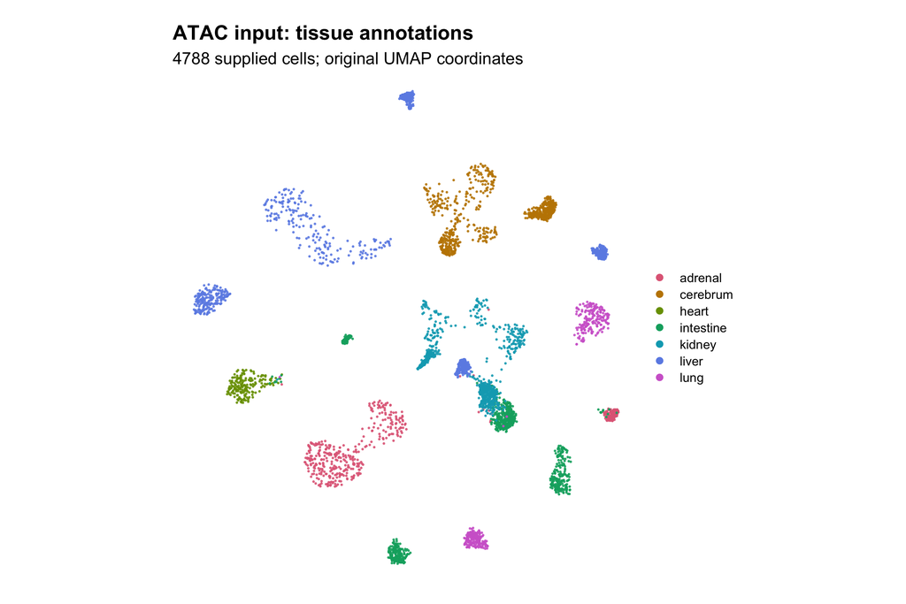

All supplied cells on the original UMAP, colored by tissue.

```r
plot_annotation_umap("tissue", "ATAC input: tissue annotations")
```

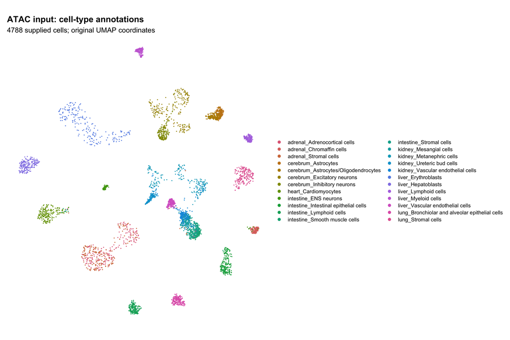

All supplied cells on the same UMAP, colored by the 24 tissue–cell-type groups.

```r
plot_annotation_umap("tissue_cell_type", "ATAC input: cell-type annotations")
```

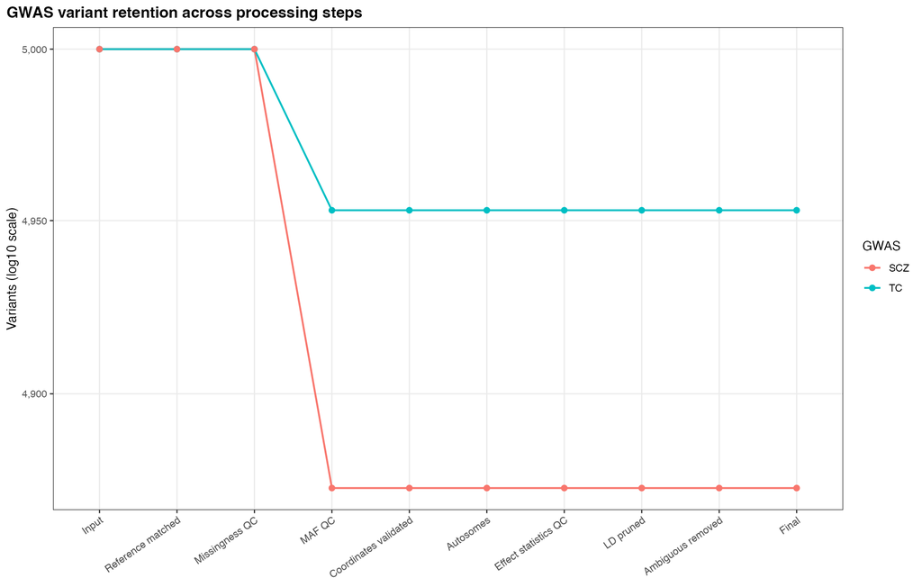

GWAS retention for TC and SCZ. LD pruning and ambiguous-variant removal were performed before these inputs were prepared; those stages are disabled here.

```r
show_figure("gwas_filtering_waterfall")
```

Coverage panels use the same cells and coordinates for both traits. For display only, per-cell totals are clipped at the within-trait 10th and 90th percentiles and rescaled to 0–1. This is the package’s display transformation; it does not change the count matrices or model predictors. Color compares cells within a trait, not absolute counts between traits.

```r
plot_coverage_umap <- function(resolution) {
  suffix <- if (resolution == "snp") ".snp_by_cell.rds" else ".peak_by_cell.rds"
  rows <- lapply(traits, function(x) {
    counts <- read_result("02_accessibility", paste0(x, suffix))
    stopifnot(setequal(colnames(counts), umap_cells))
    total <- as.numeric(Matrix::colSums(counts[, umap_cells, drop = FALSE]))
    limits <- stats::quantile(total, c(0.1, 0.9), names = FALSE)
    display <- if (diff(limits) > 0) {
      (pmin(pmax(total, limits[1]), limits[2]) - limits[1]) / diff(limits)
    } else rep(0, length(total))
    data.frame(UMAP1 = embedding[, 1], UMAP2 = embedding[, 2],
               trait = x, total = total, display = display)
  })
  data <- do.call(rbind, rows)
  data <- data[order(data$display), ]
  ggplot2::ggplot(data, ggplot2::aes(UMAP1, UMAP2, color = display)) +
    ggplot2::geom_point(size = 0.9, alpha = 1, stroke = 0) +
    ggplot2::facet_wrap(~trait, nrow = 1) +
    ggplot2::scale_color_viridis_c(option = "C", limits = c(0, 1)) +
    ggplot2::coord_equal() +
    ggplot2::theme_void(base_size = 12) +
    ggplot2::theme(strip.text = ggplot2::element_text(face = "bold", size = 13),
                   plot.title = ggplot2::element_text(face = "bold")) +
    ggplot2::labs(
      title = if (resolution == "snp") "Accessibility at GWAS SNP positions" else "Accessibility at GWAS-overlapping peaks",
      subtitle = paste(nrow(embedding), "cells per trait; within-trait 10th–90th percentile scaling"),
      color = "Relative\naccessibility"
    )
}
```

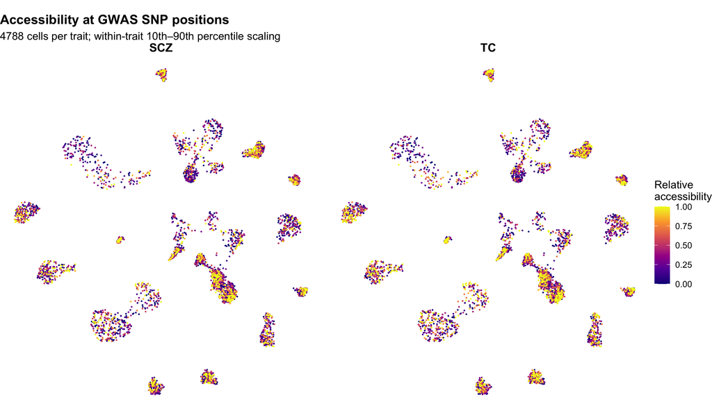

SNP fragment coverage using every supplied cell.

```r
plot_coverage_umap("snp")
```

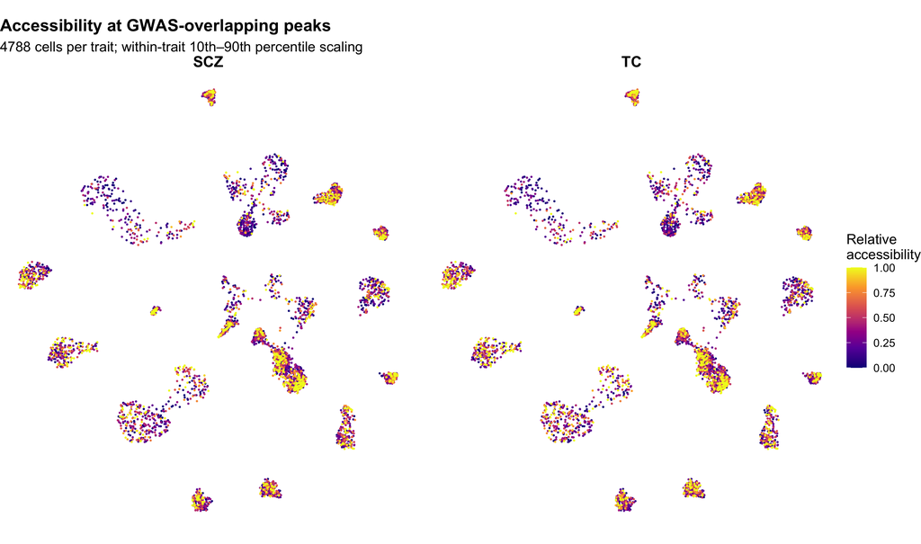

Peak-count coverage using every supplied cell.

```r
plot_coverage_umap("peak")
```

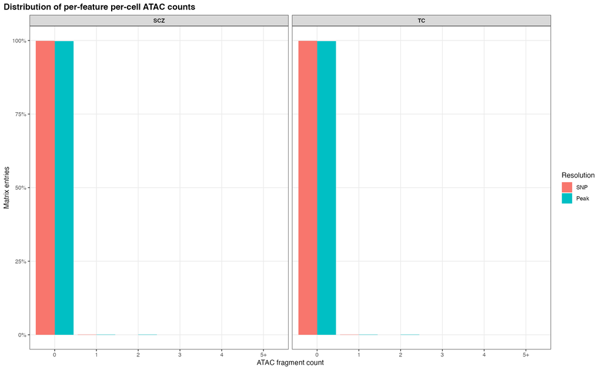

Count distributions in the SNP and peak accessibility matrices. Most entries are zero; the full-scale panel preserves that sparsity rather than hiding zero counts.

```r
show_figure("accessibility_count_distributions")
```

## 9.2 LD working matrices: complete component and off-diagonal detail

The heatmaps show the **largest connected component** of the saved covariance matrix. All features in that component are displayed, in matrix order. There is no evenly spaced selection of 100 features. This choice affects the view only; the analysis used the complete saved matrices.

Each branch has two views: the complete covariance on a linear color scale, and an off-diagonal view with the diagonal masked and a square-root color transformation. Legend labels remain the original covariance values. The second view makes small off-diagonal values visible without changing any LD calculation. The source GWAS had already been LD-pruned, and the supplied SNPs are a small random subset, so weak and sparse off-diagonal covariance is expected here. The SNP matrix contains local r² values; the peak matrix is a **response covariance**, not a correlation matrix constrained to 0–1. Entries outside the 5 Mb window are set to zero, so a banded boundary is partly imposed by the model. A connected component can span more than 5 Mb through chains of pairs; it should not be interpreted as one biological LD block.

```r
largest_complete_component <- function(sigma, blocks) {
  block <- blocks[[which.max(lengths(blocks))]]
  ids <- if (is.numeric(block)) rownames(sigma)[block] else as.character(block)
  stopifnot(length(ids) > 0, all(ids %in% rownames(sigma)))
  as.matrix(sigma[ids, ids, drop = FALSE])
}
plot_covariance <- function(view, label, off_diagonal = FALSE, legend_title = "Covariance") {
  values <- view
  if (off_diagonal) diag(values) <- NA_real_
  data <- data.frame(
    row = rep(seq_len(nrow(values)), times = ncol(values)),
    column = rep(seq_len(ncol(values)), each = nrow(values)),
    covariance = as.numeric(values)
  )
  ggplot2::ggplot(data, ggplot2::aes(column, row, fill = covariance)) +
    ggplot2::geom_raster() +
    ggplot2::scale_fill_viridis_c(
      option = "C", na.value = "grey85",
      trans = if (off_diagonal) "sqrt" else "identity",
      labels = function(x) format(x, digits = 2, trim = TRUE)
    ) +
    ggplot2::scale_y_reverse() +
    ggplot2::coord_equal(expand = FALSE) +
    ggplot2::theme_minimal(base_size = 12) +
    ggplot2::theme(panel.grid = ggplot2::element_blank()) +
    ggplot2::labs(
      title = paste(trait, label),
      subtitle = paste0(nrow(view), " features in the largest connected component; ",
                        if (off_diagonal) "diagonal masked, square-root colors" else "full matrix, linear colors"),
      x = "Feature index in genomic order", y = "Feature index in genomic order",
      fill = legend_title
    )
}
ld_view_summary <- function(view, resolution) {
  off <- view[upper.tri(view)]
  data.frame(resolution = resolution, displayed_features = nrow(view),
             off_diagonal_pairs = length(off), nonzero_pairs = sum(off != 0),
             median_off_diagonal = median(off), max_off_diagonal = max(off))
}
snp_blocks <- read_result("03_ld", paste0(trait, ".snp_blocks.rds"))
snp_view <- largest_complete_component(snp_sigma, snp_blocks)
peak_view <- largest_complete_component(peak_ld$sigma, peak_ld$block_indices)
```

```r
show_table(rbind(ld_view_summary(snp_view, "SNP"), ld_view_summary(peak_view, "Peak")), n = Inf, digits = 5)
```

| resolution | displayed_features | off_diagonal_pairs | nonzero_pairs | median_off_diagonal | max_off_diagonal |
| --- | --- | --- | --- | --- | --- |
| SNP | 211 | 22155 | 1882 | 0 | 0.53206 |
| Peak | 231 | 26565 | 2192 | 0 | 1.04316 |

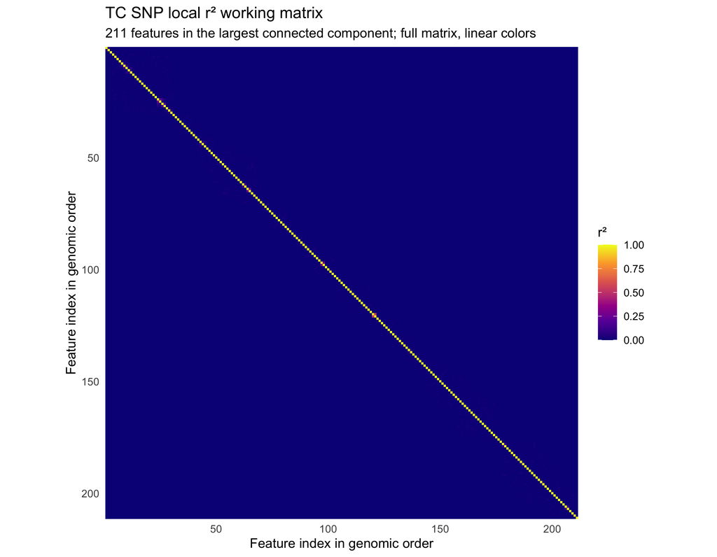

SNP local r² working matrix in the largest connected component.

```r
plot_covariance(snp_view, "SNP local r² working matrix", legend_title = "r²")
```

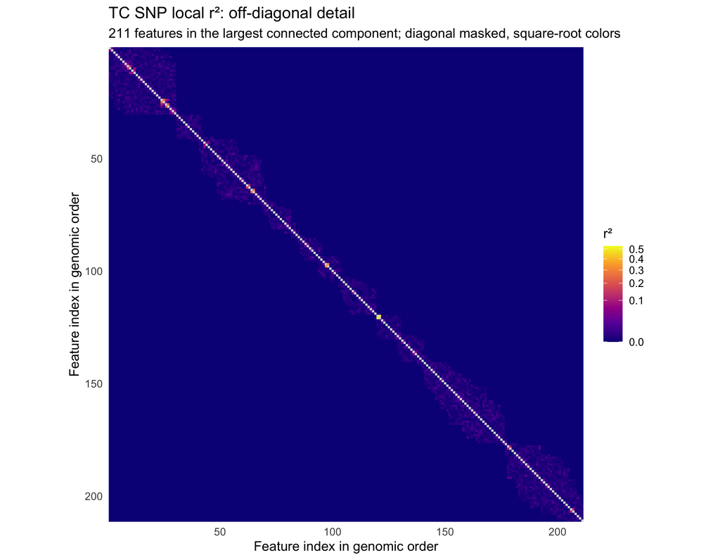

The same SNP r² values, with the diagonal masked to reveal off-diagonal structure. Colors use a square-root transformation.

```r
plot_covariance(snp_view, "SNP local r²: off-diagonal detail", TRUE, "r²")
```

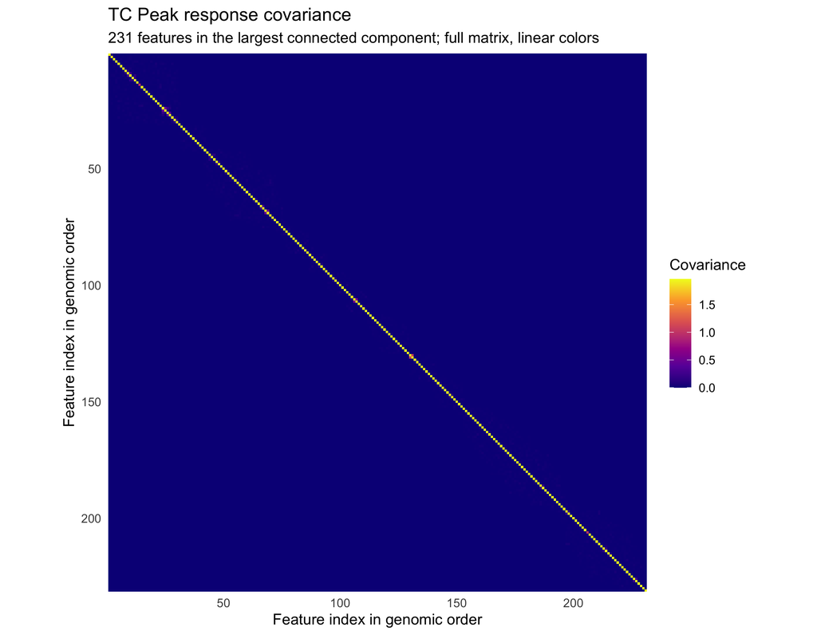

Full peak response covariance in the largest connected component.

```r
plot_covariance(peak_view, "Peak response covariance")
```

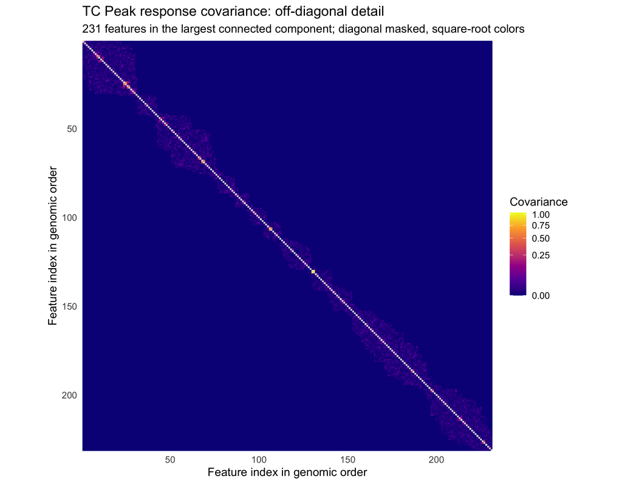

The same peak covariance values, with the diagonal masked to reveal off-diagonal structure. Colors use a square-root transformation.

```r
plot_covariance(peak_view, "Peak response covariance: off-diagonal detail", TRUE)
```

## 9.3 WRS feature specificity

The following plots summarize the saved WRS results; they do not run another sampling step. Discrete, mostly zero counts can produce similar histogram shapes across groups. Winsorization also creates mass at the truncation bounds.

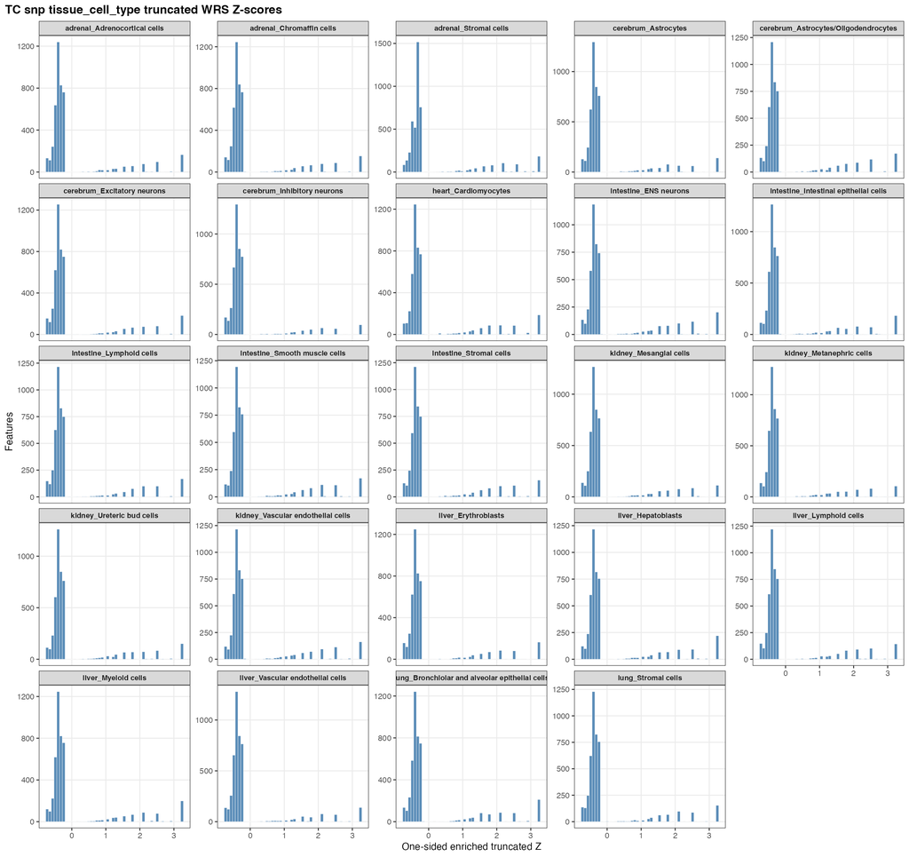

Truncated SNP WRS normal scores by cell group.

```r
show_figure(paste(trait, "snp", "tissue_cell_type", "truncated_z_hist", sep = "."))
```

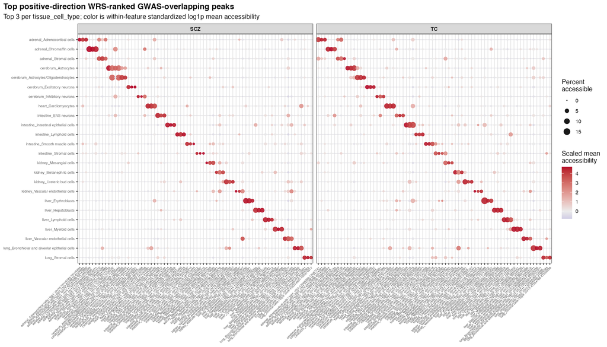

WRS-ranked peak accessibility by group. This is feature specificity, not the final trait-association test.

```r
show_figure("all_traits.top3_per_group_topPeak_wilcoxon_DotPlot")
```

## 9.4 Component and combined associations

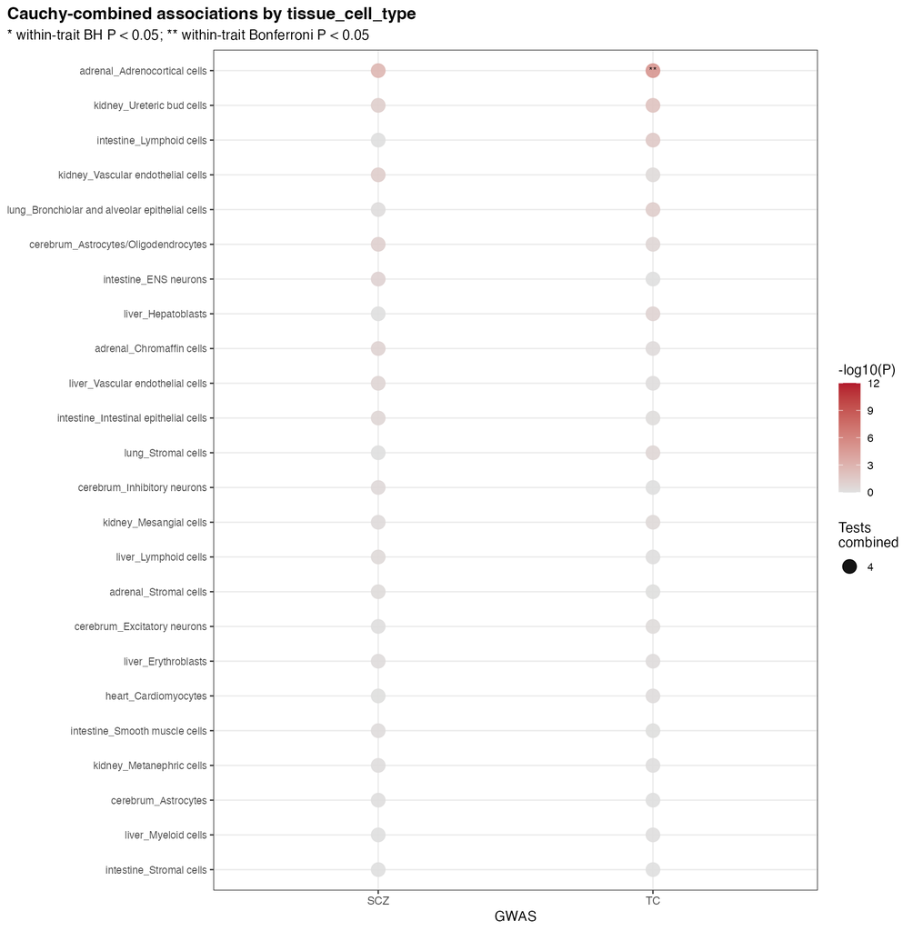

ACAT results for the TC and SCZ example subsets.

```r
show_figure("cauchy_tissue_cell_type_dotplot")
```

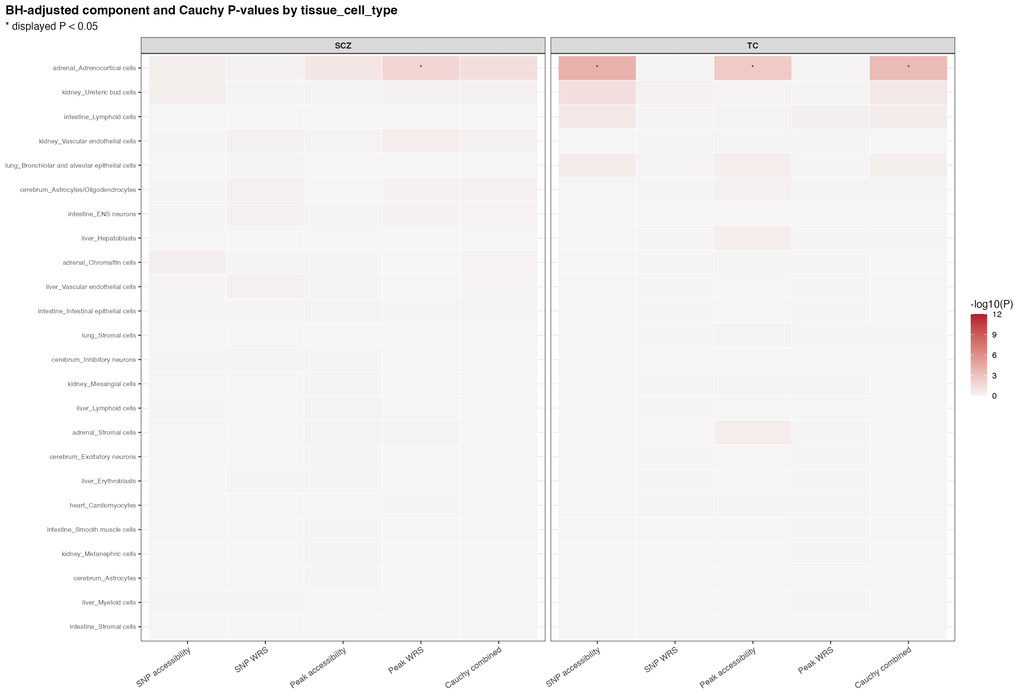

Within-trait BH-adjusted component and ACAT P-values. Stars denote BH-adjusted P < 0.05, matching the significance criterion used in the manuscript table.

```r
show_figure("cauchy_tissue_cell_type_component_heatmap_bh")
```

# 10 Verify the completed analysis

The checks below require matching SNP/reference IDs, identical cell order in both accessibility branches, completed LD calculations, and the expected number of model rows. Model status and P-value availability are reported rather than silently replacing unsuccessful fits with artificial values.

```r
summary_rows <- lapply(traits, function(x) {
  g <- read_result("02_gwas", paste0(x, ".gwas.rds"))
  ref <- read_result("02_gwas", paste0(x, ".genotype.rds"))
  snp <- read_result("02_accessibility", paste0(x, ".snp_by_cell.rds"))
  peak <- read_result("02_accessibility", paste0(x, ".peak_by_cell.rds"))
  snp_ref <- read_result("02_accessibility", paste0(x, ".snp_genotype.rds"))
  runtime <- read_result("03_ld", paste0(x, ".ld_runtime.tsv"))
  stopifnot(
    identical(as.character(g$rsid), rownames(ref)),
    identical(colnames(snp), colnames(peak)),
    identical(colnames(snp), colnames(atac)),
    identical(rownames(snp), rownames(snp_ref)),
    identical(runtime$value[runtime$setting == "status"], "COMPLETED")
  )
  data.frame(trait = x, supplied_snps = 5000L, retained_gwas = nrow(g),
             snp_features = nrow(snp), peak_features = nrow(peak),
             cells = ncol(snp), reference_individuals = ncol(ref))
})
analysis_summary <- do.call(rbind, summary_rows)
show_table(analysis_summary, n = Inf)
```

| trait | supplied_snps | retained_gwas | snp_features | peak_features | cells | reference_individuals |
| --- | --- | --- | --- | --- | --- | --- |
| TC | 5000 | 4953 | 4582 | 4901 | 4788 | 503 |
| SCZ | 5000 | 4873 | 4454 | 4825 | 4788 | 503 |

```r
for (grouping in config$model$groupings) {
  cpt <- read_result("05_models", paste0(grouping, ".component_results.tsv"))
  acat <- read_result("05_models", paste0(grouping, ".cauchy_results.tsv"))
  expected_groups <- length(unique(metadata[[grouping]]))
  stopifnot(nrow(cpt) == length(traits) * expected_groups * 4L,
            nrow(acat) == length(traits) * expected_groups,
            !anyDuplicated(cpt[, c("trait", "group", "component")]),
            !anyDuplicated(acat[, c("trait", "group")]))
  print(show_table(as.data.frame(table(grouping = rep(grouping, nrow(cpt)), status = cpt$status)), n = Inf))
  print(show_table(as.data.frame(table(trait = acat$trait,
                                      components_used = acat$n_tests_combined)), n = Inf))
}
```

| grouping | status | Freq |
| --- | --- | --- |
| tissue_cell_type | ok | 192 |

| trait | components_used | Freq |
| --- | --- | --- |
| SCZ | 4 | 24 |
| TC | 4 | 24 |

| grouping | status | Freq |
| --- | --- | --- |
| tissue | ok | 56 |

| trait | components_used | Freq |
| --- | --- | --- |
| SCZ | 4 | 7 |
| TC | 4 | 7 |

```r
show_table(as.data.frame(table(figure_manifest$status)), n = Inf)
```

| Var1 | Freq |
| --- | --- |
| generated | 47 |
| skipped | 7 |

```r
if (isTRUE(params$run_analysis)) {
  output_files <- sort(list.files(params$results_dir, recursive = TRUE, full.names = FALSE))
  output_files <- setdiff(output_files, "tutorial_run.rds")
  run_record$status <- "COMPLETED"
  run_record$completed_utc <- format(Sys.time(), tz = "UTC", usetz = TRUE)
  run_record$stage_seconds <- stage_seconds
  run_record$summary <- analysis_summary
  run_record$output_md5 <- setNames(
    unname(tools::md5sum(file.path(params$results_dir, output_files))), output_files
  )
  saveRDS(run_record, record_file)
} else {
  observed_hashes <- setNames(
    unname(tools::md5sum(file.path(params$results_dir, names(run_record$output_md5)))),
    names(run_record$output_md5)
  )
  stopifnot(identical(observed_hashes, run_record$output_md5))
}
```

```r
show_table(data.frame(stage = names(stage_seconds), elapsed_seconds = as.numeric(stage_seconds)), n = Inf)
```

| stage | elapsed_seconds |
| --- | --- |
| gwas | 1.020 |
| accessibility | 49.582 |
| ld | 10.987 |
| wrs | 3.261 |
| model | 11.226 |
| plot | 26.402 |

```r
show_table(data.frame(package = names(package_versions), version = unname(package_versions)), n = Inf)
```

| package | version |
| --- | --- |
| EPIC2 | 0.3.0 |
| Matrix | 1.7.5 |
| Seurat | 5.5.0 |
| SeuratObject | 5.4.0 |
| Signac | 1.17.1 |
| GenomicRanges | 1.64.0 |
| BiocParallel | 1.46.0 |
| Rsamtools | 2.28.0 |
| presto | 1.1.0 |
| ggplot2 | 4.0.3 |
| yaml | 2.3.12 |
| knitr | 1.51 |
| digest | 0.6.39 |

Stage times describe this example on the recorded machine and R environment; they are not a whole-dataset performance benchmark.

# 11 Full manuscript dataset

The test-data archive is separate from the full manuscript dataset. To reproduce the manuscript analysis, use the full prepared inputs and the corresponding analysis configuration, source scripts, and software version. Cell/SNP subsetting and changes to statistical implementation can change results.

A public download URL for the full manuscript dataset has not been configured.

A full-data deposit should provide a file manifest, coordinate assembly, column definitions, checksums, input preparation scripts, and the configuration used for the manuscript results. Link to original study accessions where the source data are distributed by their owners.